# Which Midlevel Luxury Car brand has the best reviews

CMSC 320 Final Tutorial

By: Sydney Hatcher

Introduction:

Thousands of people every year scour the internet reding reviews about what car to buy. Usually a lengthy and time comsuming process because different brands and their makes and models will be on different pages. Many basic obervations can be made based on the amount of stars given and the "top reviews" or what the website deems "most useful reviews". This tutorial is to provide more in depth observations into what people are actually saying about each of these brands.

About the Data:

The first step to data analysis is to choose and obtain a dataset. I chose Consumer Car Ratings and Reviews from Edmunds. Edmunds offers car reviews and insights into vehicle rankings, road tests, best of vehicle lists, editorial recommendations, etc., as well as provides values & pricing information. Edmunds is a leading website for consumers looking to buy a used or new vehicle, sell their vehicle, or estimate the costs associated with a vehicle. From comprehensive reviews and vehicle rankings to car-buying & valuation tools, Edmunds is an one-stop resource for consumers and dealership owners to ensure fair pricing and deals. Although Edumunds reviews are provided to the public in a useable format, Kaggle, a free website that contains datasets for community use, has publised csv files containing all the compiled reviews for each make and model for 62 car brands. The specifc brands I am choosing to focus on today are:

Acura

Audi

BMW

Cadillac

Genesis

Infiniti

Jaguar

Land Rover

Lexus

Lincoln

Maserati

Tesla

Mercedes Benz

Mini

Porsche

Required Tools:

You will need Python 3.6 and the following libraries: pandas: http://pandas.pydata.org/pandas-docs/stable/

numpy: https://docs.scipy.org/doc/numpy-dev/user/quickstart.html

matplotlib: http://matplotlib.org/contents.html

seaborn: https://seaborn.pydata.org/

Data Scraping:

Since the csv files are already provided, I do not need to scrape the data.

Loading/Processing the data:

We will give pandas the path to the data for each brand.

Acura: Scrapped_Car_Reviews_Acura.csv

Audi: Scrapped_Car_Reviews_Audi.csv

BMW: Scrapped_Car_Reviews_BMW.csv

Cadillac: Scrapped_Car_Review_Cadillac.csv

Genesis: Scraped_Car_Review_genesis.csv

Infiniti: Scraped_Car_Review_infiniti.csv

Jaguar: Scraped_Car_Review_jaguar.csv

Land Rover: Scraped_Car_Review_land-rover.csv

Lexus: Scraped_Car_Review_lexus.csv

Lincoln: Scraped_Car_Review_lincoln.csv

Maserati: Scraped_Car_Review_maserati.csv

Mercedes Benz: Scraped_Car_Review_mercedes-benz.csv

Mini: Scraped_Car_Review_mini.csv

Porsche: Scraped_Car_Review_porsche.csv

Tesla: Scraped_Car_Review_tesla.csv

```python
import pandas as pd
import numpy as np
import matplotlib.pyplot as plt
import seaborn as sns
```

```python
#Create data frames for each car brand's reviews
df_acura = pd.read_csv("Scrapped_Car_Reviews_Acura.csv" ,lineterminator='\n')
df_audi = pd.read_csv("Scrapped_Car_Reviews_Audi.csv", lineterminator = '\n')
df_bmw = pd.read_csv("Scrapped_Car_Reviews_BMW.csv" ,lineterminator='\n')
df_cadillac = pd.read_csv("Scrapped_Car_Review_Cadillac.csv" ,lineterminator='\n')
df_genesis = pd.read_csv("Scraped_Car_Review_genesis.csv" ,lineterminator='\n')
df_infiniti = pd.read_csv("Scraped_Car_Review_infiniti.csv" ,lineterminator='\n')
df_jaguar = pd.read_csv("Scraped_Car_Review_jaguar.csv" ,lineterminator='\n')
df_landrover = pd.read_csv("Scraped_Car_Review_land-rover.csv" ,lineterminator='\n')
df_lexus = pd.read_csv("Scraped_Car_Review_lexus.csv" ,lineterminator='\n')
df_lincoln = pd.read_csv("Scraped_Car_Review_lincoln.csv" ,lineterminator='\n')
df_maserati = pd.read_csv("Scraped_Car_Review_maserati.csv" ,lineterminator='\n')
df_mercedesbenz = pd.read_csv("Scraped_Car_Review_mercedes-benz.csv" ,lineterminator='\n')
df_mini = pd.read_csv("Scraped_Car_Review_mini.csv" ,lineterminator='\n')
df_porsche = pd.read_csv("Scraped_Car_Review_porsche.csv" ,lineterminator='\n')
df_tesla = pd.read_csv("Scraped_Car_Review_tesla.csv" ,lineterminator='\n')
```

Display the first 10 rows of each data frame

```python
df_acura.head(10)
```

|  | Unnamed: 0 | Review_Date | Author_Name | Vehicle_Title | Review_Title | Review | Rating\r |
| --- | --- | --- | --- | --- | --- | --- | --- |
| 0 | 0 | on 11/10/17 22:53 PM (PST) | V MEL | 2014 Acura RLX Sedan Technology Package 4dr Se... | Good car | This Acura RLX has been a great vehicle for ... | 4.000 |
| 1 | 1 | on 07/03/17 09:06 AM (PDT) | RLXer | 2014 Acura RLX Sedan Technology Package 4dr Se... | RLXer | Fast lots of room good gas mileage if you kee... | 4.000 |
| 2 | 2 | on 01/02/17 17:02 PM (PST) | Dpaprocki | 2014 Acura RLX Sedan Advance Package 4dr Sedan... | Wish I had a better RLX story | 2014 Acura RLX, with advanced package, purcha... | 1.000 |
| 3 | 3 | on 02/22/16 14:48 PM (PST) | Ed Koval | 2014 Acura RLX Sedan 4dr Sedan (3.5L 6cyl 6A) | Almost Perfect | There is a lot to like about this car, and fr... | 4.000 |
| 4 | 4 | on 11/02/15 18:50 PM (PST) | SS | 2014 Acura RLX Sedan Navigation 4dr Sedan (3.5... | Overall, great car but it does have some problems | I'm very happy with the performance, handling... | 3.000 |
| 5 | 5 | on 10/23/15 23:45 PM (PDT) | Jacqueline Scott | 2014 Acura RLX Sedan Navigation 4dr Sedan (3.5... | Drives Great "IF" You Can Get it to Start! | Purchased my 2014 RLX in May 2014. Other tha... | 4.000 |
| 6 | 6 | on 07/24/14 10:15 AM (PDT) | billg8 | 2014 Acura RLX Sedan Navigation 4dr Sedan (3.5... | Really Good Car | This car is alot better than reviewed from my... | 4.750 |
| 7 | 7 | on 05/07/14 16:15 PM (PDT) | s_sc | 2014 Acura RLX Sedan Advance Package 4dr Sedan... | Bad design or bad quality? | I bought my RLX-ADV about 4 months ago and on... | 3.000 |
| 8 | 8 | on 03/10/14 19:08 PM (PDT) | rlxregrets | 2014 Acura RLX Sedan Technology Package 4dr Se... | RLX Rattles down the road since purchase- no s... | I noticed rattles coming from front suspensio... | 2.625 |
| 9 | 9 | on 08/11/13 18:33 PM (PDT) | gman124 | 2014 Acura RLX Sedan Navigation 4dr Sedan (3.5... | nice car | all in all, a very nice car. but not sure if ... | 3.750 |

```python
df_audi.head(10)
```

|  | Unnamed: 0 | Review_Date | Author_Name | Vehicle_Title | Review_Title | Review | Rating\r |
| --- | --- | --- | --- | --- | --- | --- | --- |
| 0 | 0 | on 07/11/18 19:05 PM (PDT) | ARLE | 2018 Audi SQ5 SUV 3.0T Prestige quattro 4dr SU... | BEST ALL AROUND PURPOSE CROSSOVER SUV | I have never seen or driven a car like this b... | 5.0 |
| 1 | 1 | on 06/24/18 12:50 PM (PDT) | Mark Weiner | 2018 Audi SQ5 SUV 3.0T Prestige quattro 4dr SU... | Best car | This is a wonderful car. The technology is v... | 5.0 |
| 2 | 2 | on 05/02/18 11:45 AM (PDT) | mycwf.pic | 2018 Audi SQ5 SUV 3.0T Premium Plus quattro 4d... | Great Buy | Do your home work | 5.0 |
| 3 | 3 | on 12/07/17 14:12 PM (PST) | Rich | 2018 Audi SQ5 SUV 3.0T Premium Plus quattro 4d... | Fun Car | Great ride. Loaded with technology. Steering ... | 5.0 |
| 4 | 4 | on 10/25/17 15:54 PM (PDT) | Al | 2018 Audi SQ5 SUV 3.0T Prestige quattro 4dr SU... | Best luxury SUV w/ perfect comfort/sport balance | Very happy with choosing the 2018 Audi SQ5 pr... | 5.0 |
| 5 | 5 | on 10/14/17 08:24 AM (PDT) | TN | 2018 Audi SQ5 SUV 3.0T Prestige quattro 4dr SU... | Great car!!! | Still new. Everything seems working perfectly... | 5.0 |
| 6 | 6 | on 07/16/17 08:19 AM (PDT) | Aspen SQ5 | 2018 Audi SQ5 SUV 3.0T Premium Plus quattro 4d... | Exceptionally balanced vehicle | Ive owned alot of cars since the late 70's, m... | 5.0 |
| 7 | 7 | on 04/22/18 20:44 PM (PDT) | Ajay | 2017 Audi SQ5 SUV 3.0T Premium Plus quattro 4d... | A rare find! | I have owned a 2006 BMW X5, 4.4V8, 2009 Merce... | 4.0 |
| 8 | 8 | on 03/21/17 18:25 PM (PDT) | Tom | 2017 Audi SQ5 SUV 3.0T Prestige quattro 4dr SU... | What a Cayenne Turbo driver thinks of this car | This will surprise you. Forget the BMW X3 and... | 5.0 |
| 9 | 9 | on 02/28/17 05:53 AM (PST) | Tommie 555 | 2017 Audi SQ5 SUV 3.0T Premium Plus quattro 4d... | Hold On | Punch the gas and hold on, this baby will fly... | 5.0 |

```python
df_bmw.head(10)
```

|  | Unnamed: 0 | Review_Date | Author_Name | Vehicle_Title | Review_Title | Review | Rating\r |
| --- | --- | --- | --- | --- | --- | --- | --- |
| 0 | 0 | on 05/02/18 12:10 PM (PDT) | Shaf | 2014 BMW X1 SUV xDrive28i 4dr SUV AWD (2.0L 4c... | Love it | Beautiful car. Love all aspects | 5.0 |
| 1 | 1 | on 04/10/18 19:01 PM (PDT) | RogerCVC | 2014 BMW X1 SUV xDrive28i 4dr SUV AWD (2.0L 4c... | OK with Reservations | We picked this car as a CPO from a BMW dealer... | 3.0 |
| 2 | 2 | on 10/24/17 18:33 PM (PDT) | Mike | 2014 BMW X1 SUV xDrive28i 4dr SUV AWD (2.0L 4c... | Love this car | Get ride of the run flats. If you like to d... | 5.0 |
| 3 | 3 | on 08/08/17 19:30 PM (PDT) | Jacob H | 2014 BMW X1 SUV xDrive28i 4dr SUV AWD (2.0L 4c... | Worst Purchase I've ever made | 1.\tDealership was a joke to work with, lied ... | 1.0 |
| 4 | 4 | on 03/17/17 15:05 PM (PDT) | d. b. | 2014 BMW X1 SUV xDrive28i 4dr SUV AWD (2.0L 4c... | car 1 | Handy as a pocket on a shirt. | 5.0 |
| 5 | 5 | on 02/25/17 21:54 PM (PST) | CG | 2014 BMW X1 SUV xDrive28i 4dr SUV AWD (2.0L 4c... | A Great Sporty SUV! | Drives like a nice little SUV sports car. I w... | 5.0 |
| 6 | 6 | on 02/15/17 10:59 AM (PST) | robert d | 2014 BMW X1 SUV sDrive28i 4dr SUV (2.0L 4cyl T... | owner for two years . a great grocery ge... | 35 mpg on a 3000 mile trip 24+intown in winte... | 4.0 |
| 7 | 7 | on 01/21/17 17:52 PM (PST) | Roy | 2014 BMW X1 SUV sDrive28i 4dr SUV (2.0L 4cyl T... | Great handling vehicle with in need of improve... | Purchased 2014 X1 fully loaded with M-Sport p... | 4.0 |
| 8 | 8 | on 11/20/16 15:11 PM (PST) | S Flicker | 2014 BMW X1 SUV xDrive28i 4dr SUV AWD (2.0L 4c... | A BMW 3 Series as a small SUV | The great handling and braking of a 3 series ... | 5.0 |
| 9 | 9 | on 06/09/16 05:11 AM (PDT) | PatD | 2014 BMW X1 SUV xDrive28i 4dr SUV AWD (2.0L 4c... | Tak ada fun right out of my BMW | My first BMW and I'm now caught in the Takata... | 1.0 |

```python
df_cadillac.head(10)
```

|  | Unnamed: 0 | Review_Date | Author_Name | Vehicle_Title | Review_Title | Review | Rating\r |
| --- | --- | --- | --- | --- | --- | --- | --- |
| 0 | 0 | on 11/07/17 07:56 AM (PST) | James Landi | 2007 Cadillac XLR-V Convertible 2dr Convertibl... | An incomparable luxury roadster | It's hard for me not to take second, third an... | 5.000 |
| 1 | 1 | on 04/26/08 11:33 AM (PDT) | John Cutsey | 2007 Cadillac XLR-V Convertible 2dr Convertibl... | Awsome Machine | As stated in my review above it has been the ... | 5.000 |
| 2 | 2 | on 01/18/08 20:41 PM (PST) | 2007 XLR-V CA | 2007 Cadillac XLR-V Convertible 2dr Convertibl... | 2007 Cadillac XLR-V | I had this car for about a year. I have had a... | 5.000 |
| 3 | 3 | on 02/19/07 16:51 PM (PST) | sunidhi | 2007 Cadillac XLR-V Convertible 2dr Convertibl... | The 2007 Cadillac XLR-V | I think that this car is really well built. ... | 4.500 |
| 4 | 4 | on 12/07/06 11:26 AM (PST) | 2007 Cadillac XLR-V | 2007 Cadillac XLR-V Convertible 2dr Convertibl... | Fast | I like fast cars and this one is just great. ... | 4.750 |
| 5 | 5 | on 10/17/06 14:06 PM (PDT) | AL | 2007 Cadillac XLR-V Convertible 2dr Convertibl... | Love It | I just wanted something different than my BMW... | 4.750 |
| 6 | 6 | on 10/12/06 17:50 PM (PDT) | goglobal | 2007 Cadillac XLR-V Convertible 2dr Convertibl... | XLR-V is awesome | This car is fantastic. I would highly recomm... | 5.000 |
| 7 | 7 | on 10/09/06 11:34 AM (PDT) | Bob K | 2007 Cadillac XLR-V Convertible 2dr Convertibl... | Much Better Than Expected | Finally, a car that is as good or better than... | 5.000 |
| 8 | 8 | on 08/26/06 18:56 PM (PDT) | Laura | 2007 Cadillac XLR-V Convertible 2dr Convertibl... | What a Thrill Ride! | I have had my XLR-V for three months. The on... | 4.875 |
| 9 | 9 | on 12/06/17 12:24 PM (PST) | MJL | 2009 Cadillac XLR-V Convertible 2dr Convertibl... | Claasic Cadillac Sports Car | The car is pretty advanced for being 9 years ... | 5.000 |

```python
df_genesis.head(10)
```

|  | Unnamed: 0 | Review_Date | Author_Name | Vehicle_Title | Review_Title | Review | Rating\r |
| --- | --- | --- | --- | --- | --- | --- | --- |
| 0 | 0 | on 12/27/17 09:37 AM (PST) | Mike | 2017 Genesis G90 Sedan Premium 4dr Sedan AWD (... | This car is the real deal | I have never posted an online review of a car... | 5 |
| 1 | 1 | on 12/02/17 06:18 AM (PST) | Mark H | 2017 Genesis G90 Sedan Premium 4dr Sedan AWD (... | G90 - An S Class Competitor Selling For 35% Less | Be prepared to be amazed at what you get for ... | 5 |
| 2 | 2 | on 11/02/17 12:43 PM (PDT) | LTHAtlanta | 2017 Genesis G90 Sedan Premium 4dr Sedan (3.3L... | World class luxury at an excellent price | Genesis G90Took delivery of a Genesis G90 in ... | 5 |
| 3 | 3 | on 10/08/17 19:50 PM (PDT) | Tod L. | 2017 Genesis G90 Sedan Ultimate 4dr Sedan (5.0... | Amazing | This car is fantastic | 5 |
| 4 | 4 | on 10/02/17 08:36 AM (PDT) | Barry B | 2017 Genesis G90 Sedan Ultimate 4dr Sedan AWD ... | Built to Compete | The G90 Ultimate built to compete w/Audi A8L,... | 5 |
| 5 | 5 | on 09/17/17 20:32 PM (PDT) | tim mcc | 2017 Genesis G90 Sedan Premium 4dr Sedan AWD (... | dealership/repairs | my g90 has less than 200 miles in shop for tw... | 1 |
| 6 | 6 | on 09/05/17 10:25 AM (PDT) | Nortic | 2017 Genesis G90 Sedan Ultimate 4dr Sedan (5.0... | Best car I ever owned | Great value. Comes fully loaded. No options t... | 5 |
| 7 | 7 | on 08/21/17 16:46 PM (PDT) | Richard N | 2017 Genesis G90 Sedan Ultimate 4dr Sedan (5.0... | My car is getting lots of respect from Mercede... | Somehow, the G90 looks perfect to my country ... | 4 |
| 8 | 8 | on 08/13/17 11:15 AM (PDT) | Jones123 | 2017 Genesis G90 Sedan Ultimate 4dr Sedan (5.0... | Test Driving Queen | The car has all the luxury that you expect fr... | 5 |
| 9 | 9 | on 08/03/17 12:28 PM (PDT) | Rick | 2017 Genesis G90 Sedan Premium 4dr Sedan AWD (... | Traded my Lexus LS for a Genesis G90! | I've owned Lexus cars exclusively for the pas... | 1 |

```python
df_infiniti.head(10)
```

|  | Unnamed: 0 | Review_Date | Author_Name | Vehicle_Title | Review_Title | Review | Rating\r |
| --- | --- | --- | --- | --- | --- | --- | --- |
| 0 | 0 | on 04/19/18 05:08 AM (PDT) | gaboy | 2017 INFINITI QX70 SUV 4dr SUV (3.7L 6cyl 7A) | Best deal i've ever gotten | I have a good friend who has a 2014 version u... | 5.0 |
| 1 | 1 | on 01/24/18 10:01 AM (PST) | Jeff | 2017 INFINITI QX70 SUV 4dr SUV (3.7L 6cyl 7A) | My QX 70 Baby | Wonderful SUV and u feel like a million bucks... | 5.0 |
| 2 | 2 | on 09/17/17 17:45 PM (PDT) | Justine | 2017 INFINITI QX70 SUV 4dr SUV AWD (3.7L 6cyl 7A) | My 3rd one! | I love this car so much, I've owned 3. Altho... | 5.0 |
| 3 | 3 | on 05/13/17 05:46 AM (PDT) | Ron | 2017 INFINITI QX70 SUV 4dr SUV AWD (3.7L 6cyl 7A) | Love the look. Hate the car | Ride is stiff. rattles my dentures. No room i... | 4.0 |
| 4 | 4 | on 01/30/17 09:24 AM (PST) | JWK | 2017 INFINITI QX70 SUV 4dr SUV AWD (3.7L 6cyl 7A) | Meh...not really that impressed | I rented this car and spent 900 miles in it (... | 3.0 |
| 5 | 5 | on 11/28/16 20:07 PM (PST) | Don Finley | 2017 INFINITI QX70 SUV 4dr SUV (3.7L 6cyl 7A) | 2017 QX70 Limited | Owned a 2004 FX35, was the best car I've ever... | 5.0 |
| 6 | 6 | on 10/10/17 10:05 AM (PDT) | HD | 2014 INFINITI QX70 SUV 4dr SUV AWD (5.0L 8cyl 7A) | Fastest naturally aspirated SUV (still!) | 0-60 in 4.8 seconds. *This* is the first sta... | 5.0 |
| 7 | 7 | on 12/15/16 18:17 PM (PST) | albert schreiber | 2014 INFINITI QX70 SUV 4dr SUV (3.7L 6cyl 7A) | when you hit passing gear about 60 mph hang on | it is a great car this is my third 2 fx35 ... | 5.0 |
| 8 | 8 | on 11/19/16 05:13 AM (PST) | StasB | 2014 INFINITI QX70 SUV 4dr SUV AWD (5.0L 8cyl 7A) | Fantastic vehicle | This is not my first Infiniti, I had over 190... | 5.0 |
| 9 | 9 | on 07/21/16 09:33 AM (PDT) | Beth Ann | 2014 INFINITI QX70 SUV 4dr SUV AWD (3.7L 6cyl 7A) | Love it! | Beautiful, comfortable car with all the bells... | 5.0 |

```python
df_jaguar.head(10)
```

|  | Unnamed: 0 | Review_Date | Author_Name | Vehicle_Title | Review_Title | Review | Rating\r |
| --- | --- | --- | --- | --- | --- | --- | --- |
| 0 | 0 | on 05/07/15 14:32 PM (PDT) | rick161 | 1999 Jaguar XK-Series Coupe XK8 2dr Coupe | Champagne motoring for fish 'n chips money. | My '99 XK8 convertible is my dream car, after... | 5.000 |
| 1 | 1 | on 05/01/08 22:30 PM (PDT) | ex-fan | 1999 Jaguar XK-Series Coupe XK8 2dr Coupe | Stay away | After 80,000 miles, the timing chains came of... | 3.750 |
| 2 | 2 | on 06/07/11 19:03 PM (PDT) | tomeyeman | 1999 Jaguar XK-Series Convertible XK8 2dr Conv... | So-So car | I traded a 98 Porsche Boxster for a 99 Jaguar... | 2.750 |
| 3 | 3 | on 05/05/11 12:27 PM (PDT) | remsenburg | 1999 Jaguar XK-Series Convertible XK8 2dr Conv... | Great value, but requires some patience.... | As someone who has owned two other Jaguars, a... | 4.000 |
| 4 | 4 | on 04/15/10 08:49 AM (PDT) | Sutzme | 1999 Jaguar XK-Series Convertible XK8 2dr Conv... | Worth the headaches | Bought this gem used with 21K miles on it. Go... | 4.625 |
| 5 | 5 | on 11/23/09 16:46 PM (PST) | allen/kym | 1999 Jaguar XK-Series Convertible XK8 2dr Conv... | Great bang for your buck | I just bought my Jag Xk8 convertible a few mo... | 4.875 |
| 6 | 6 | on 03/27/08 14:31 PM (PDT) | One more thought | 1999 Jaguar XK-Series Convertible XK8 2dr Conv... | Mixed feelings | I love the looks and the ride is exceptional ... | 4.500 |
| 7 | 7 | on 10/11/07 11:17 AM (PDT) | Markas | 1999 Jaguar XK-Series Convertible XK8 2dr Conv... | A great old girl | I have a friend who owned this car and was mo... | 4.875 |
| 8 | 8 | on 08/13/07 12:27 PM (PDT) | greyfox | 1999 Jaguar XK-Series Convertible XK8 2dr Conv... | Reality | Great looking but no real substance. At 6500... | 3.375 |
| 9 | 9 | on 05/20/05 07:29 AM (PDT) | Richard Hill | 1999 Jaguar XK-Series Convertible XK8 2dr Conv... | The Brits can still make a great car | I had resisted buying another Jaguar since my... | 4.500 |

```python
df_landrover.head(10)
```

|  | Unnamed: 0 | Review_Date | Author_Name | Vehicle_Title | Review_Title | Review | Rating\r |
| --- | --- | --- | --- | --- | --- | --- | --- |
| 0 | 0 | on 02/13/18 20:14 PM (PST) | BVA | 2015 Land Rover Range Rover Evoque SUV Pure Pl... | Very Good SUV | This is an execellent SUV, but you have to kn... | 4.0 |
| 1 | 1 | on 10/04/17 18:13 PM (PDT) | PJ | 2015 Land Rover Range Rover Evoque SUV Pure Pl... | Stylish | I would suggest that you shop around. The dea... | 5.0 |
| 2 | 2 | on 01/20/17 16:41 PM (PST) | Kerry | 2015 Land Rover Range Rover Evoque SUV Pure Pl... | Don't buy this car!!! | This car is a death trap. It has been in the ... | 1.0 |
| 3 | 3 | on 11/29/16 18:40 PM (PST) | Stacye | 2015 Land Rover Range Rover Evoque SUV Pure Pl... | Bluetooth Nightmare | I have had nothing but problems with the Blue... | 3.0 |
| 4 | 4 | on 10/01/16 05:23 AM (PDT) | Ray DeLuca | 2015 Land Rover Range Rover Evoque SUV Pure Pl... | So far so good! | Bought the 2 door with 2200 miles. I've had n... | 5.0 |
| 5 | 5 | on 09/11/16 14:05 PM (PDT) | Mrs. M | 2015 Land Rover Range Rover Evoque SUV Pure Pl... | Do not buy!! | I bought the Evoque in a bit of a hurry becau... | 1.0 |
| 6 | 6 | on 04/04/16 14:40 PM (PDT) | ken duff | 2015 Land Rover Range Rover Evoque SUV Pure Pl... | Lemon | Bought December 2014, nothing but trouble. In... | 1.0 |
| 7 | 7 | on 03/02/16 21:14 PM (PST) | Joseph Teyssandier | 2015 Land Rover Range Rover Evoque SUV Pure Pl... | A Ford Escape wearing a dinner jacket. | All looks and no actions. A brand that I alwa... | 1.0 |
| 8 | 8 | on 10/19/15 02:32 AM (PDT) | Melissa | 2015 Land Rover Range Rover Evoque SUV Pure Pl... | Hands Down Safest SUV | I leased a 2015 Land Rover Range Rover Evoque... | 5.0 |
| 9 | 9 | on 10/01/15 16:13 PM (PDT) | Lynn C | 2015 Land Rover Range Rover Evoque SUV Pure 4d... | I expected so much more! | First the good: This is a great looking car ... | 3.0 |

```python
df_lexus.head(10)
```

|  | Unnamed: 0 | Review_Date | Author_Name | Vehicle_Title | Review_Title | Review | Rating\r |
| --- | --- | --- | --- | --- | --- | --- | --- |
| 0 | 0 | on 10/20/14 17:15 PM (PDT) | zebani | 2004 Lexus IS 300 Sedan E-Shift 4dr Sedan (3.0... | 2004 IS300 Automatic - | My wife and I owned over 20 vehicles in the l... | 4.500 |
| 1 | 1 | on 08/28/12 07:13 AM (PDT) | slow_jim | 2004 Lexus IS 300 Sedan E-Shift 4dr Sedan (3.0... | Terrible gas mileage, no back seat room | Surprisingly little room for a luxury car. My... | 3.000 |
| 2 | 2 | on 06/23/10 15:17 PM (PDT) | RJ Rafael | 2004 Lexus IS 300 Sedan 4dr Sedan (3.0L 6cyl 5M) | Thank God i bought a 5 speed | I know this sound generic but "I love my car!... | 4.875 |
| 3 | 3 | on 07/01/09 23:02 PM (PDT) | not impressed | 2004 Lexus IS 300 Sedan 4dr Sedan (3.0L 6cyl 5M) | Not impressed | Bought new in 04, hated it so traded my mom f... | 3.125 |
| 4 | 4 | on 04/22/09 17:54 PM (PDT) | Jon | 2004 Lexus IS 300 Sedan 4dr Sedan (3.0L 6cyl 5M) | Nice!! | Drove BMW 3 series, G35, Volvo S60 and IS 300... | 4.375 |
| 5 | 5 | on 03/05/09 21:34 PM (PST) | admanc | 2004 Lexus IS 300 Sedan 4dr Sedan (3.0L 6cyl 5M) | Just got it | I test drove the 2004 IS300 against a beautif... | 4.625 |
| 6 | 6 | on 02/20/07 08:37 AM (PST) | jbdusf | 2004 Lexus IS 300 Sedan 4dr Sedan (3.0L 6cyl 5M) | WOW! | I was looking to buy a new car and was thinki... | 4.875 |
| 7 | 7 | on 01/23/07 12:30 PM (PST) | Tom | 2004 Lexus IS 300 Sedan 4dr Sedan (3.0L 6cyl 5M) | Want BMW performance with reliability? | This car has superb handling as it almost beg... | 4.750 |
| 8 | 8 | on 12/17/05 12:25 PM (PST) | Nickster | 2004 Lexus IS 300 Sedan 4dr Sedan (3.0L 6cyl 5M) | Amazing Car | After owning BMWs and Audis, the quality that... | 4.875 |
| 9 | 9 | on 11/13/05 16:39 PM (PST) | cholodeperu | 2004 Lexus IS 300 Sedan 4dr Sedan (3.0L 6cyl 5M) | good looking car | Bought the car brand new back in January 04. ... | 3.750 |

```python
df_lincoln.head(10)
```

|  | Unnamed: 0 | Review_Date | Author_Name | Vehicle_Title | Review_Title | Review | Rating\r |
| --- | --- | --- | --- | --- | --- | --- | --- |
| 0 | 0 | on 06/21/17 01:30 AM (PDT) | Justin Cravalho | 2008 Lincoln Navigator SUV 4dr SUV 4WD (5.4L 8... | I love my Navigator | Be sure you're ready to be coddled in the ult... | 5.000 |
| 1 | 1 | on 02/11/16 21:39 PM (PST) | Gaelon Ball | 2008 Lincoln Navigator SUV 4dr SUV (5.4L 8cyl 6A) | Amazing 08 Navigator | I bought my Navigator a few months ago and ab... | 5.000 |
| 2 | 2 | on 11/15/15 14:16 PM (PST) | Chris | 2008 Lincoln Navigator SUV 4dr SUV (5.4L 8cyl 6A) | I had this car for 10 years | This is a wonderful SUV very comfortable very... | 5.000 |
| 3 | 3 | on 01/13/12 10:31 AM (PST) | azt1 | 2008 Lincoln Navigator SUV 4dr SUV 4WD (5.4L 8... | Comfortable and Roomy. | I've had my Navigator for a few months now. I... | 4.500 |
| 4 | 4 | on 08/24/09 11:21 AM (PDT) | bal | 2008 Lincoln Navigator SUV 4dr SUV 4WD (5.4L 8... | Nice SUV | This car is an overall good vehicle. It has r... | 4.375 |
| 5 | 5 | on 07/16/09 19:55 PM (PDT) | kev | 2008 Lincoln Navigator SUV 4dr SUV 4WD (5.4L 8... | Great travel vehicle | I bought this 6 months ago. it took a few we... | 4.625 |
| 6 | 6 | on 06/04/09 10:44 AM (PDT) | sevenstw | 2008 Lincoln Navigator SUV 4dr SUV 4WD (5.4L 8... | Luxury Built Ford Tough | The exterior chrome and square gauges have a ... | 4.625 |
| 7 | 7 | on 03/21/09 10:19 AM (PDT) | TRS | 2008 Lincoln Navigator SUV 4dr SUV 4WD (5.4L 8... | Best One Yet | This is my third Navigator. All have been 2 y... | 4.625 |
| 8 | 8 | on 11/28/08 17:25 PM (PST) | Laura | 2008 Lincoln Navigator SUV 4dr SUV (5.4L 8cyl 6A) | Luv It | Love it! This is the most comfortable car I h... | 5.000 |
| 9 | 9 | on 09/07/08 08:48 AM (PDT) | jnd | 2008 Lincoln Navigator SUV 4dr SUV 4WD (5.4L 8... | Solid in every way | This is our second Navigator and this is much... | 4.875 |

```python
df_maserati.head(10)
```

|  | Unnamed: 0 | Review_Date | Author_Name | Vehicle_Title | Review_Title | Review | Rating\r |
| --- | --- | --- | --- | --- | --- | --- | --- |
| 0 | 0 | on 01/01/05 19:28 PM (PST) | Jeff | 2004 Maserati Spyder Convertible Cambiocorsa 2... | Maserati Thrill Ride | I bought my Maserati Spyder Cambiocorsa \rin ... | 4.875 |
| 1 | 1 | on 12/05/04 06:07 AM (PST) | Francie | 2004 Maserati Spyder Convertible Cambiocorsa 2... | My second Spyder | I got the very first Maserati Spyder delivere... | 4.750 |
| 2 | 2 | on 12/04/04 15:28 PM (PST) | West8 | 2004 Maserati Spyder Convertible GT 2dr Conver... | Fast & Fun | After owning several comparable cars in the p... | 4.375 |
| 3 | 3 | on 10/28/04 00:00 AM (PDT) | KLAMIA2001 | 2004 Maserati Spyder Convertible Cambiocorsa 2... | ITALIANS RULE | THIS IS MY THIRD MASERATI, A 2002, 2003 \r& A... | 5.000 |
| 4 | 4 | on 09/22/04 00:00 AM (PDT) | d blair | 2004 Maserati Spyder Convertible Cambiocorsa 2... | Midlife Crisis?? I don't think so! | Ok so I am a 55 year old man who has \rcome t... | 4.750 |
| 5 | 5 | on 09/07/04 00:00 AM (PDT) | NJDevil | 2004 Maserati Spyder Convertible Cambiocorsa 2... | Fun for the Money | This car is a Ferrari in a Maserati \rbody. T... | 4.500 |
| 6 | 6 | on 07/24/04 00:00 AM (PDT) | willsshot | 2004 Maserati Spyder Convertible Cambiocorsa 2... | outstanding | the design is spectacular, with \rperformance... | 5.000 |
| 7 | 7 | on 05/17/04 00:00 AM (PDT) | alexthegreat | 2004 Maserati Spyder Convertible GT 2dr Conver... | Best. Car. Ever. | Best. Car. Ever. Great looking, rides \rgreat... | 4.750 |
| 8 | 8 | on 04/09/04 00:00 AM (PDT) | scottjm | 2004 Maserati Spyder Convertible GT 2dr Conver... | Better than expected | After driving the BMW M3 SMG Coup the \rpast ... | 4.875 |
| 9 | 9 | on 03/20/04 00:00 AM (PST) | spyderrob | 2004 Maserati Spyder Convertible Cambiocorsa 2... | excelent car | I previously owned 3 mercedes bens 500 \rsl ... | 4.875 |

```python
df_mercedesbenz.head(10)
```

|  | Unnamed: 0 | Review_Date | Author_Name | Vehicle_Title | Review_Title | Review | Rating\r |
| --- | --- | --- | --- | --- | --- | --- | --- |
| 0 | 0 | on 10/25/17 13:28 PM (PDT) | George | 2002 Mercedes-Benz CLK-Class CLK55 AMG CLK55 A... | Mercedes fun in sun | Clk is pricey on repairs . Tires wear out fas... | 3.000 |
| 1 | 1 | on 11/06/06 20:38 PM (PST) | John Campen | 2002 Mercedes-Benz CLK-Class CLK55 AMG CLK55 A... | AMG Rocket! | Purchased this 2002 CLK55 AMG in April 2006 w... | 5.000 |
| 2 | 2 | on 12/02/05 16:45 PM (PST) | Fast Machine | 2002 Mercedes-Benz CLK-Class CLK55 AMG CLK55 A... | Fine Coupe | I purchased this in October of 2005 with 25,0... | 5.000 |
| 3 | 3 | on 10/15/05 07:37 AM (PDT) | mbenza | 2002 Mercedes-Benz CLK-Class CLK55 AMG CLK55 A... | CLK55 | Initial electrical problems with the interior... | 4.250 |
| 4 | 4 | on 08/09/05 20:22 PM (PDT) | augie | 2002 Mercedes-Benz CLK-Class CLK55 AMG CLK55 A... | Best combo of comfort and speed! | This car has been great. We picked it up in J... | 5.000 |
| 5 | 5 | on 07/28/05 02:15 AM (PDT) | Walter | 2002 Mercedes-Benz CLK-Class CLK55 AMG CLK55 A... | It's all about the hoursepower | This is the most fun car I've ever driven. W... | 4.250 |
| 6 | 6 | on 07/16/05 14:55 PM (PDT) | TheLino | 2002 Mercedes-Benz CLK-Class CLK55 AMG CLK55 A... | Outstanding | I purchased the 2002 CLK55 cabriolet with 28,... | 4.625 |
| 7 | 7 | on 08/16/04 00:00 AM (PDT) | r.r | 2002 Mercedes-Benz CLK-Class CLK55 AMG CLK55 A... | better late than never | just bought my first amg and it won't \rbe my... | 4.125 |
| 8 | 8 | on 01/20/04 00:00 AM (PST) | Eddie C | 2002 Mercedes-Benz CLK-Class CLK55 AMG CLK55 A... | Exceptional Vehicle | This is perhaps one of the best \rvehicles I ... | 4.625 |
| 9 | 9 | on 12/11/03 00:00 AM (PST) | trd277 | 2002 Mercedes-Benz CLK-Class CLK55 AMG CLK55 A... | Perfect Car | Best of all worlds! Incredibly fast, \ramazi... | 4.875 |

```python
df_mini.head(10)
```

|  | Unnamed: 0 | Review_Date | Author_Name | Vehicle_Title | Review_Title | Review | Rating\r |
| --- | --- | --- | --- | --- | --- | --- | --- |
| 0 | 0 | on 07/31/18 17:57 PM (PDT) | Lynn | 2002 MINI Cooper Hatchback S 2dr Hatchback (1.... | TOP GEAR | I got my mini one year ago (2017) as a "TOY".... | 4.000 |
| 1 | 1 | on 07/12/16 08:54 AM (PDT) | Barb Wilcox | 2002 MINI Cooper Hatchback 2dr Hatchback (1.6L... | A very nice SECOND car. | Number one would be the extraordinarily high ... | 4.000 |
| 2 | 2 | on 07/07/10 03:58 AM (PDT) | tywashin | 2002 MINI Cooper Hatchback 2dr Hatchback (1.6L... | Best small car on the road! | Well, I have only owned it for about two mont... | 4.500 |
| 3 | 3 | on 06/06/10 23:11 PM (PDT) | jennyj | 2002 MINI Cooper Hatchback 2dr Hatchback (1.6L... | Stay Away! | I bought this car from the previous owner who... | 2.125 |
| 4 | 4 | on 09/30/08 18:31 PM (PDT) | ghost | 2002 MINI Cooper Hatchback 2dr Hatchback (1.6L... | Very upset!! | I purchased my 2002 Mini last Aug. 2007. I h... | 2.500 |
| 5 | 5 | on 06/09/08 19:52 PM (PDT) | Jim from Indy | 2002 MINI Cooper Hatchback 2dr Hatchback (1.6L... | Kudos to this car, so far | This car handles almost as well as my 1991 Do... | 5.000 |
| 6 | 6 | on 05/26/08 07:05 AM (PDT) | cheryl, | 2002 MINI Cooper Hatchback 2dr Hatchback (1.6L... | "uncle" | This car is so much fun to drive, rivaling o... | 3.875 |
| 7 | 7 | on 04/03/08 20:11 PM (PDT) | Fun in Del Mar | 2002 MINI Cooper Hatchback 2dr Hatchback (1.6L... | Clutch and Transmission Failure | I have had a lot of trouble initially with th... | 3.250 |
| 8 | 8 | on 02/08/08 08:33 AM (PST) | T Ritchison | 2002 MINI Cooper Hatchback S 2dr Hatchback (1.... | Mighty | My Mini S, makes me smile. It's everything I ... | 4.875 |
| 9 | 9 | on 10/01/07 12:10 PM (PDT) | Lisa | 2002 MINI Cooper Hatchback S 2dr Hatchback (1.... | 2002 Mini Cooper S | This car has been a real joy to drive. Not on... | 4.875 |

```python
df_porsche.head(10)
```

|  | Unnamed: 0 | Review_Date | Author_Name | Vehicle_Title | Review_Title | Review | Rating\r |
| --- | --- | --- | --- | --- | --- | --- | --- |
| 0 | 0 | on 08/28/18 13:31 PM (PDT) | Chris | 2015 Porsche Macan SUV Turbo 4dr SUV AWD (3.6L... | Porsche Macan is a Beast | I owned a Porsche Cayenne for two years and e... | 5.0 |
| 1 | 1 | on 06/17/18 17:30 PM (PDT) | Phil Fair | 2015 Porsche Macan SUV S 4dr SUV AWD (3.0L 6cy... | Outstanding ride! | Love my 2015 Porsche Macan S SUV, but please ... | 5.0 |
| 2 | 2 | on 05/16/18 11:27 AM (PDT) | Steven | 2015 Porsche Macan SUV S 4dr SUV AWD (3.0L 6cy... | Pretty and comfy | Great looking vehicle with the most comfortab... | 4.0 |
| 3 | 3 | on 05/15/18 19:22 PM (PDT) | Zw | 2015 Porsche Macan SUV S 4dr SUV AWD (3.0L 6cy... | Once you've gone Porsche, it's hard to go back | Crossover that drives like a Porsche- I outgr... | 5.0 |
| 4 | 4 | on 11/11/17 07:20 AM (PST) | george toccalino | 2015 Porsche Macan SUV Turbo 4dr SUV AWD (3.6L... | The 911 SUV | Fun to drive SUV:very close to handling like ... | 5.0 |
| 5 | 5 | on 09/12/16 19:03 PM (PDT) | Michele | 2015 Porsche Macan SUV S 4dr SUV AWD (3.0L 6cy... | Forgot I am driving an SUV | The performance and handling are the obvious ... | 5.0 |
| 6 | 6 | on 06/12/16 18:15 PM (PDT) | Sam Suen | 2015 Porsche Macan SUV S 4dr SUV AWD (3.0L 6cy... | Best handling SUV on the market still going st... | It might cost a bit more than the competition... | 5.0 |
| 7 | 7 | on 03/22/16 20:47 PM (PDT) | Jeri buxton | 2015 Porsche Macan SUV Turbo 4dr SUV AWD (3.6L... | Pocket rocket | Too fast, too sophisticated, reliable and one... | 5.0 |
| 8 | 8 | on 03/01/16 20:02 PM (PST) | Bke | 2015 Porsche Macan SUV S 4dr SUV AWD (3.0L 6cy... | Great Suv - drives like a sports cat |  | 5.0 |
| 9 | 9 | on 01/13/16 12:18 PM (PST) | Tom | 2015 Porsche Macan SUV S 4dr SUV AWD (3.0L 6cy... | Sport Sedan in an SUV Body | I had mixed feelings about buying this car be... | 5.0 |

```python
df_tesla.head(10)
```

|  | Unnamed: 0 | Review_Date | Author_Name | Vehicle_Title | Review_Title | Review | Rating\r |
| --- | --- | --- | --- | --- | --- | --- | --- |
| 0 | 0 | on 08/30/18 15:36 PM (PDT) | TN | 2018 Tesla Model X SUV 75D 4dr SUV AWD (electr... | Not for everyone | Model X is unique. Either you like be it or h... | 5.0 |
| 1 | 1 | on 07/04/18 17:15 PM (PDT) | Ryan W | 2018 Tesla Model X SUV 100D 4dr SUV AWD (elect... | Crazy good, despite many small flaws | A lot of the existing reviews online, includi... | 4.0 |
| 2 | 2 | on 06/21/18 05:22 AM (PDT) | Bamboo | 2017 Tesla Model X SUV 100D 4dr SUV AWD (elect... | If only my X can fly | Like most consumers, I've owned five differen... | 5.0 |
| 3 | 3 | on 04/07/18 15:01 PM (PDT) | Mel | 2017 Tesla Model X SUV 100D 4dr SUV AWD (elect... | Little disappointed. | Owned car for three more months and it had to... | 4.0 |
| 4 | 4 | on 12/30/17 21:45 PM (PST) | Dallen Ormond | 2017 Tesla Model X SUV P100D 4dr SUV AWD (elec... | Fantastic | In the past 12 years I have owned 18 differen... | 5.0 |
| 5 | 5 | on 12/29/17 08:46 AM (PST) | Tiger Driver | 2017 Tesla Model X SUV 75D 4dr SUV AWD (electr... | The best crossover SUV ever | The front end cost can be reduced by state an... | 5.0 |
| 6 | 6 | on 08/03/18 04:59 AM (PDT) | Brian K | 2016 Tesla Model X SUV 75D 4dr SUV AWD (electr... | Still amazed! | We went to Tesla in 2016 to place our $1,000 ... | 5.0 |
| 7 | 7 | on 12/29/17 07:22 AM (PST) | Alan Savenor | 2016 Tesla Model X SUV P90D 4dr SUV AWD (elect... | Go Electric! | EV range is great. Easy to refuel at supercha... | 5.0 |
| 8 | 8 | on 12/15/17 21:31 PM (PST) | bgp | 2016 Tesla Model X SUV 90D 4dr SUV AWD (electr... | Model X is fun to drive but has glitches | My Model X has konked out twice and had to be... | 4.0 |
| 9 | 9 | on 11/26/17 05:17 AM (PST) | P90D Test Driver | 2016 Tesla Model X SUV P90D 4dr SUV AWD (elect... | If you want quick acceleration, buy this car!!! | Yes it's all electric, and yes, it's pricey a... | 4.0 |

# Data Tidying:

Now that all the data is in dataframes, we can remove unwanted rows of information. First, we start by removing the column of author_name to protect the privacy of the reviewers. Also because the each file has different amounts of data ranging from 77 rows to 10,000+, in order to get to get a mixture of years I will take a random sample for each.

```python
#Drop the Author column from the Acura dataframe
df_acura.drop("Author_Name", axis=1,inplace=True)
df_acura.head(10)
```

|  | Unnamed: 0 | Review_Date | Vehicle_Title | Review_Title | Review | Rating\r |
| --- | --- | --- | --- | --- | --- | --- |
| 0 | 0 | on 11/10/17 22:53 PM (PST) | 2014 Acura RLX Sedan Technology Package 4dr Se... | Good car | This Acura RLX has been a great vehicle for ... | 4.000 |
| 1 | 1 | on 07/03/17 09:06 AM (PDT) | 2014 Acura RLX Sedan Technology Package 4dr Se... | RLXer | Fast lots of room good gas mileage if you kee... | 4.000 |
| 2 | 2 | on 01/02/17 17:02 PM (PST) | 2014 Acura RLX Sedan Advance Package 4dr Sedan... | Wish I had a better RLX story | 2014 Acura RLX, with advanced package, purcha... | 1.000 |
| 3 | 3 | on 02/22/16 14:48 PM (PST) | 2014 Acura RLX Sedan 4dr Sedan (3.5L 6cyl 6A) | Almost Perfect | There is a lot to like about this car, and fr... | 4.000 |
| 4 | 4 | on 11/02/15 18:50 PM (PST) | 2014 Acura RLX Sedan Navigation 4dr Sedan (3.5... | Overall, great car but it does have some problems | I'm very happy with the performance, handling... | 3.000 |
| 5 | 5 | on 10/23/15 23:45 PM (PDT) | 2014 Acura RLX Sedan Navigation 4dr Sedan (3.5... | Drives Great "IF" You Can Get it to Start! | Purchased my 2014 RLX in May 2014. Other tha... | 4.000 |
| 6 | 6 | on 07/24/14 10:15 AM (PDT) | 2014 Acura RLX Sedan Navigation 4dr Sedan (3.5... | Really Good Car | This car is alot better than reviewed from my... | 4.750 |
| 7 | 7 | on 05/07/14 16:15 PM (PDT) | 2014 Acura RLX Sedan Advance Package 4dr Sedan... | Bad design or bad quality? | I bought my RLX-ADV about 4 months ago and on... | 3.000 |
| 8 | 8 | on 03/10/14 19:08 PM (PDT) | 2014 Acura RLX Sedan Technology Package 4dr Se... | RLX Rattles down the road since purchase- no s... | I noticed rattles coming from front suspensio... | 2.625 |
| 9 | 9 | on 08/11/13 18:33 PM (PDT) | 2014 Acura RLX Sedan Navigation 4dr Sedan (3.5... | nice car | all in all, a very nice car. but not sure if ... | 3.750 |

```python
#Get random sample of 250 acura reviews
df_acura_sample = df_acura.sample(250)
df_acura_sample.head()
```

|  | Unnamed: 0 | Review_Date | Vehicle_Title | Review_Title | Review | Rating\r |
| --- | --- | --- | --- | --- | --- | --- |
| 3005 | 3005 | on 05/24/16 13:52 PM (PDT) | 2015 Acura TLX Sedan Technology Package 4dr Se... | Terrible transmission |  | 2.000 |
| 3030 | 3030 | on 10/12/15 12:40 PM (PDT) | 2015 Acura TLX Sedan Technology Package 4dr Se... | Good fuel economy paired with good performance | Great car so far. Nice and responsive, yes t... | 5.000 |
| 1980 | 1980 | on 06/15/07 07:09 AM (PDT) | 2007 Acura TL Type-S Type-S 4dr Sedan w/Summer... | Much Better than an Accord, BMW, Lexus | This is a great buy for an entry-level luxury... | 4.750 |
| 5559 | 5559 | on 12/08/10 05:35 AM (PST) | 2011 Acura MDX SUV Technology and Entertainmen... | False MPG Claim! | I have a 2010 MDX Tech Package/entertainment ... | 3.500 |
| 4008 | 4008 | on 01/11/07 18:51 PM (PST) | 2006 Acura RL Sedan 3.5 4dr Sedan AWD w/Navi S... | My favorite car, unfortunately totaled | Fun car to drive, unfortunately I totaled it ... | 4.875 |

```python
#Drop the Author column from the Audi dataframe
df_audi.drop("Author_Name", axis=1, inplace=True)
df_audi.head(10)
```

|  | Unnamed: 0 | Review_Date | Vehicle_Title | Review_Title | Review | Rating\r |
| --- | --- | --- | --- | --- | --- | --- |
| 0 | 0 | on 07/11/18 19:05 PM (PDT) | 2018 Audi SQ5 SUV 3.0T Prestige quattro 4dr SU... | BEST ALL AROUND PURPOSE CROSSOVER SUV | I have never seen or driven a car like this b... | 5.0 |
| 1 | 1 | on 06/24/18 12:50 PM (PDT) | 2018 Audi SQ5 SUV 3.0T Prestige quattro 4dr SU... | Best car | This is a wonderful car. The technology is v... | 5.0 |
| 2 | 2 | on 05/02/18 11:45 AM (PDT) | 2018 Audi SQ5 SUV 3.0T Premium Plus quattro 4d... | Great Buy | Do your home work | 5.0 |
| 3 | 3 | on 12/07/17 14:12 PM (PST) | 2018 Audi SQ5 SUV 3.0T Premium Plus quattro 4d... | Fun Car | Great ride. Loaded with technology. Steering ... | 5.0 |
| 4 | 4 | on 10/25/17 15:54 PM (PDT) | 2018 Audi SQ5 SUV 3.0T Prestige quattro 4dr SU... | Best luxury SUV w/ perfect comfort/sport balance | Very happy with choosing the 2018 Audi SQ5 pr... | 5.0 |
| 5 | 5 | on 10/14/17 08:24 AM (PDT) | 2018 Audi SQ5 SUV 3.0T Prestige quattro 4dr SU... | Great car!!! | Still new. Everything seems working perfectly... | 5.0 |
| 6 | 6 | on 07/16/17 08:19 AM (PDT) | 2018 Audi SQ5 SUV 3.0T Premium Plus quattro 4d... | Exceptionally balanced vehicle | Ive owned alot of cars since the late 70's, m... | 5.0 |
| 7 | 7 | on 04/22/18 20:44 PM (PDT) | 2017 Audi SQ5 SUV 3.0T Premium Plus quattro 4d... | A rare find! | I have owned a 2006 BMW X5, 4.4V8, 2009 Merce... | 4.0 |
| 8 | 8 | on 03/21/17 18:25 PM (PDT) | 2017 Audi SQ5 SUV 3.0T Prestige quattro 4dr SU... | What a Cayenne Turbo driver thinks of this car | This will surprise you. Forget the BMW X3 and... | 5.0 |
| 9 | 9 | on 02/28/17 05:53 AM (PST) | 2017 Audi SQ5 SUV 3.0T Premium Plus quattro 4d... | Hold On | Punch the gas and hold on, this baby will fly... | 5.0 |

```python
#Get random sample of 250 audi reviews
df_audi_sample = df_audi.sample(250)
df_audi_sample.head(10)
```

|  | Unnamed: 0 | Review_Date | Vehicle_Title | Review_Title | Review | Rating\r |
| --- | --- | --- | --- | --- | --- | --- |
| 908 | 908 | on 04/02/08 17:48 PM (PDT) | 2001 Audi A6 Sedan 2.7T Quattro AWD 4dr Sedan ... | The best and worst car I've driven | The audi a6 2.7t is one of the best cars I've... | 4.500 |
| 1126 | 1126 | on 11/16/04 22:04 PM (PST) | 2000 Audi A6 Sedan 2.7T quattro 4dr Sedan AWD | Never Again | My 2000 Audi A6 2.7T Sedan was probably a can... | 3.500 |
| 3344 | 3344 | on 06/25/05 17:49 PM (PDT) | 2004 Audi A8 Sedan L quattro AWD 4dr Sedan (4.... | Disappointed | First car was taken back by dealership after ... | 3.625 |
| 3852 | 3852 | on 01/03/06 11:46 AM (PST) | 2003 Audi TT Convertible 180hp Fwd 2dr Roadste... | Even Used Its Great ! | I purchased a certified, brilliant red roadst... | 4.875 |
| 2999 | 2999 | on 01/07/09 09:59 AM (PST) | 2007 Audi Q7 SUV 3.6 Premium quattro 4dr SUV A... | This will be my last Audi | I traded in a lemon 2002 A6 in for the Q7. Wi... | 2.750 |
| 2471 | 2471 | on 03/30/05 19:21 PM (PST) | 2005 Audi S4 Wagon Avant quattro AWD 4dr Wagon... | good car so far | only one problem as the diagnostics computer ... | 4.750 |
| 2050 | 2050 | on 06/04/15 18:10 PM (PDT) | 2015 Audi A3 Sedan 2.0 TFSI Prestige quattro 4... | Horrible experience with Audi A3 Cabriolet | I leased a new 2015 Audi A3 Cabriolet from Au... | 2.625 |
| 4950 | 4950 | on 05/23/04 00:00 AM (PDT) | 2004 Audi A4 Wagon 1.8T Avant quattro AWD 4dr ... | A pleasure to drive | Car is easy to handle; seats are \rcimfortabl... | 4.875 |
| 1078 | 1078 | on 01/20/17 11:25 AM (PST) | 2017 Audi A6 Sedan 3.0T Prestige quattro 4dr S... | Most awesome car I have ever owned | This car is the best car I have ever owned. G... | 5.000 |
| 1256 | 1256 | on 05/03/18 19:23 PM (PDT) | 2016 Audi A6 Sedan 3.0T Premium Plus quattro 4... | blistering acceleration but with unreliable | We purchased our 2016 3.0T prem plus A6 in Ju... | 3.000 |

```python
#Drop Author column from BMW dataframe
df_bmw.drop("Author_Name", axis=1, inplace=True)
df_bmw.head(10)
```

|  | Unnamed: 0 | Review_Date | Vehicle_Title | Review_Title | Review | Rating\r |
| --- | --- | --- | --- | --- | --- | --- |
| 0 | 0 | on 05/02/18 12:10 PM (PDT) | 2014 BMW X1 SUV xDrive28i 4dr SUV AWD (2.0L 4c... | Love it | Beautiful car. Love all aspects | 5.0 |
| 1 | 1 | on 04/10/18 19:01 PM (PDT) | 2014 BMW X1 SUV xDrive28i 4dr SUV AWD (2.0L 4c... | OK with Reservations | We picked this car as a CPO from a BMW dealer... | 3.0 |
| 2 | 2 | on 10/24/17 18:33 PM (PDT) | 2014 BMW X1 SUV xDrive28i 4dr SUV AWD (2.0L 4c... | Love this car | Get ride of the run flats. If you like to d... | 5.0 |
| 3 | 3 | on 08/08/17 19:30 PM (PDT) | 2014 BMW X1 SUV xDrive28i 4dr SUV AWD (2.0L 4c... | Worst Purchase I've ever made | 1.\tDealership was a joke to work with, lied ... | 1.0 |
| 4 | 4 | on 03/17/17 15:05 PM (PDT) | 2014 BMW X1 SUV xDrive28i 4dr SUV AWD (2.0L 4c... | car 1 | Handy as a pocket on a shirt. | 5.0 |
| 5 | 5 | on 02/25/17 21:54 PM (PST) | 2014 BMW X1 SUV xDrive28i 4dr SUV AWD (2.0L 4c... | A Great Sporty SUV! | Drives like a nice little SUV sports car. I w... | 5.0 |
| 6 | 6 | on 02/15/17 10:59 AM (PST) | 2014 BMW X1 SUV sDrive28i 4dr SUV (2.0L 4cyl T... | owner for two years . a great grocery ge... | 35 mpg on a 3000 mile trip 24+intown in winte... | 4.0 |
| 7 | 7 | on 01/21/17 17:52 PM (PST) | 2014 BMW X1 SUV sDrive28i 4dr SUV (2.0L 4cyl T... | Great handling vehicle with in need of improve... | Purchased 2014 X1 fully loaded with M-Sport p... | 4.0 |
| 8 | 8 | on 11/20/16 15:11 PM (PST) | 2014 BMW X1 SUV xDrive28i 4dr SUV AWD (2.0L 4c... | A BMW 3 Series as a small SUV | The great handling and braking of a 3 series ... | 5.0 |
| 9 | 9 | on 06/09/16 05:11 AM (PDT) | 2014 BMW X1 SUV xDrive28i 4dr SUV AWD (2.0L 4c... | Tak ada fun right out of my BMW | My first BMW and I'm now caught in the Takata... | 1.0 |

```python
#Get random sample of 300 BMW reviews
df_bmw_sample = df_bmw.sample(300)
df_bmw_sample.head(10)
```

|  | Unnamed: 0 | Review_Date | Vehicle_Title | Review_Title | Review | Rating\r |
| --- | --- | --- | --- | --- | --- | --- |
| 4439 | 4439 | on 06/01/16 13:01 PM (PDT) | 2014 BMW 3 Series Diesel 328d xDrive 4dr Sedan... | 2014 328D Xdrive | IMHO the recommended intervals for fluid chan... | 5.000 |
| 3015 | 3015 | on 02/06/04 00:00 AM (PST) | 2001 BMW Z3 Convertible 2.5i 2dr Roadster (2.5... | Can't beat a BMW | Sorry to Honda and Infiniti and all \rother c... | 4.875 |
| 3436 | 3436 | on 10/17/12 18:49 PM (PDT) | 2012 BMW 5 Series Sedan 528i xDrive 4dr Sedan ... | Most boring BMW I've ever owned... | Lets just say that I've had the car for 3 wee... | 3.000 |
| 2050 | 2050 | on 03/06/02 00:00 AM (PST) | 2000 BMW 7 Series Sedan 740iL 4dr Sedan | A Class of Excellence | This is simply one of the best vehicles one c... | 4.875 |
| 7978 | 7978 | on 03/12/03 00:00 AM (PST) | 2001 BMW M5 Sedan 4dr Sedan (4.9L 8cyl 6M) | Freude am Fahren | This is the best car I've ever, and I \rmean ... | 4.500 |
| 6043 | 6043 | on 09/28/03 00:00 AM (PDT) | 2000 BMW 3 Series Convertible 323Ci 2dr Conver... | excellant car | I traded in a 1999 Mercedes for this \rvehicl... | 5.000 |
| 4417 | 4417 | on 12/22/16 14:40 PM (PST) | 2014 BMW 3 Series Sedan 328i 4dr Sedan (2.0L 4... | 2014 BMW 328i | Wow what a car!!!! For the first time in my ... | 5.000 |
| 1968 | 1968 | on 03/05/06 14:25 PM (PST) | 2001 BMW 7 Series Sedan 740i 4dr Sedan (4.4L 8... | The Smaller 7 Series | Have found that this 740I has all the pleasur... | 4.875 |
| 5125 | 5125 | on 10/26/16 09:36 AM (PDT) | 2015 BMW 3 Series Sedan 328i SULEV 4dr Sedan (... | Don't invest in this vehicle | I purchase this car Feb 2016. It was 2015 BM... | 3.000 |
| 7906 | 7906 | on 09/03/10 18:43 PM (PDT) | 2008 BMW M5 Sedan 4dr Sedan (5.0L 10cyl 7AM) | Great Car | I've had the car for nearly a year. Great dai... | 4.500 |

```python
#Drop Author column from Cadillac dataframe
df_cadillac.drop("Author_Name", axis=1,inplace=True)
df_cadillac.head(10)
```

|  | Unnamed: 0 | Review_Date | Vehicle_Title | Review_Title | Review | Rating\r |
| --- | --- | --- | --- | --- | --- | --- |
| 0 | 0 | on 11/07/17 07:56 AM (PST) | 2007 Cadillac XLR-V Convertible 2dr Convertibl... | An incomparable luxury roadster | It's hard for me not to take second, third an... | 5.000 |
| 1 | 1 | on 04/26/08 11:33 AM (PDT) | 2007 Cadillac XLR-V Convertible 2dr Convertibl... | Awsome Machine | As stated in my review above it has been the ... | 5.000 |
| 2 | 2 | on 01/18/08 20:41 PM (PST) | 2007 Cadillac XLR-V Convertible 2dr Convertibl... | 2007 Cadillac XLR-V | I had this car for about a year. I have had a... | 5.000 |
| 3 | 3 | on 02/19/07 16:51 PM (PST) | 2007 Cadillac XLR-V Convertible 2dr Convertibl... | The 2007 Cadillac XLR-V | I think that this car is really well built. ... | 4.500 |
| 4 | 4 | on 12/07/06 11:26 AM (PST) | 2007 Cadillac XLR-V Convertible 2dr Convertibl... | Fast | I like fast cars and this one is just great. ... | 4.750 |
| 5 | 5 | on 10/17/06 14:06 PM (PDT) | 2007 Cadillac XLR-V Convertible 2dr Convertibl... | Love It | I just wanted something different than my BMW... | 4.750 |
| 6 | 6 | on 10/12/06 17:50 PM (PDT) | 2007 Cadillac XLR-V Convertible 2dr Convertibl... | XLR-V is awesome | This car is fantastic. I would highly recomm... | 5.000 |
| 7 | 7 | on 10/09/06 11:34 AM (PDT) | 2007 Cadillac XLR-V Convertible 2dr Convertibl... | Much Better Than Expected | Finally, a car that is as good or better than... | 5.000 |
| 8 | 8 | on 08/26/06 18:56 PM (PDT) | 2007 Cadillac XLR-V Convertible 2dr Convertibl... | What a Thrill Ride! | I have had my XLR-V for three months. The on... | 4.875 |
| 9 | 9 | on 12/06/17 12:24 PM (PST) | 2009 Cadillac XLR-V Convertible 2dr Convertibl... | Claasic Cadillac Sports Car | The car is pretty advanced for being 9 years ... | 5.000 |

```python
#Create random sample of 250 Cadillac reviews
df_cadillac_sample = df_cadillac.sample(250)
df_cadillac_sample.head(10)
```

|  | Unnamed: 0 | Review_Date | Vehicle_Title | Review_Title | Review | Rating\r |
| --- | --- | --- | --- | --- | --- | --- |
| 177 | 177 | on 02/26/03 00:00 AM (PST) | 2003 Cadillac DeVille Sedan DTS 4dr Sedan (4.6... | Great Car | Drive the car everyday, no problems, \rhas mo... | 4.875 |
| 2867 | 2867 | on 07/21/11 13:49 PM (PDT) | 2005 Cadillac SRX SUV Rwd 4dr SUV (3.6L 6cyl 5A) | 2005 cadillac srx | this car has been well taken care of but to b... | 4.000 |
| 2762 | 2762 | on 12/10/17 08:51 AM (PST) | 2013 Cadillac SRX SUV Performance 4dr SUV AWD ... | My SRX 4 Should have stayed in FLORIDA | I've owned a 2006 STS since brand new. Love ... | 5.000 |
| 904 | 904 | on 11/28/05 21:22 PM (PST) | 2005 Cadillac CTS Sedan 4dr Sedan (2.8L 6cyl 6M) | Cadillac Builds a Winner | My new 2.8L CTS rocks. The design, performanc... | 4.875 |
| 838 | 838 | on 04/27/15 10:37 AM (PDT) | 2011 Cadillac CTS Sedan Luxury 4dr Sedan (3.0L... | Love my CaddyO. USA, USA! | For less $$ than entry level new Accord, Camr... | 4.750 |
| 2600 | 2600 | on 03/27/16 18:34 PM (PDT) | 2006 Cadillac STS Sedan V8 4dr Sedan (4.6L 8cy... | Dude. Yes. | Finally got my grubby paws on a V8 STS, after... | 5.000 |
| 1472 | 1472 | on 07/27/03 00:00 AM (PDT) | 2003 Cadillac Escalade SUV AWD 4dr SUV (6.0L 8... | cadillac escalade | This a very impressive vehicle. The \roptions... | 4.875 |
| 854 | 854 | on 08/01/12 13:02 PM (PDT) | 2005 Cadillac CTS Sedan 4dr Sedan (3.6L 6cyl 6M) | 291,000 and still going strong | I boughtmy 2005 CTS brand new in Oakland at t... | 4.500 |
| 134 | 134 | on 05/03/09 23:53 PM (PDT) | 2003 Cadillac DeVille Sedan 4dr Sedan (4.6L 8c... | Didn't Cadillac stand for class? | Second owner car only had 40K on it. within t... | 3.125 |
| 420 | 420 | on 06/03/02 00:00 AM (PDT) | 2000 Cadillac DeVille Sedan DHS 4dr Sedan | Superb car !!! | I drive this car for 2 years now and it's abs... | 4.875 |

```python
#Drop author column from Genesis dataframe
df_genesis.drop("Author_Name", axis=1, inplace=True)
df_genesis.head(10)
```

|  | Unnamed: 0 | Review_Date | Vehicle_Title | Review_Title | Review | Rating\r |
| --- | --- | --- | --- | --- | --- | --- |
| 0 | 0 | on 12/27/17 09:37 AM (PST) | 2017 Genesis G90 Sedan Premium 4dr Sedan AWD (... | This car is the real deal | I have never posted an online review of a car... | 5 |
| 1 | 1 | on 12/02/17 06:18 AM (PST) | 2017 Genesis G90 Sedan Premium 4dr Sedan AWD (... | G90 - An S Class Competitor Selling For 35% Less | Be prepared to be amazed at what you get for ... | 5 |
| 2 | 2 | on 11/02/17 12:43 PM (PDT) | 2017 Genesis G90 Sedan Premium 4dr Sedan (3.3L... | World class luxury at an excellent price | Genesis G90Took delivery of a Genesis G90 in ... | 5 |
| 3 | 3 | on 10/08/17 19:50 PM (PDT) | 2017 Genesis G90 Sedan Ultimate 4dr Sedan (5.0... | Amazing | This car is fantastic | 5 |
| 4 | 4 | on 10/02/17 08:36 AM (PDT) | 2017 Genesis G90 Sedan Ultimate 4dr Sedan AWD ... | Built to Compete | The G90 Ultimate built to compete w/Audi A8L,... | 5 |
| 5 | 5 | on 09/17/17 20:32 PM (PDT) | 2017 Genesis G90 Sedan Premium 4dr Sedan AWD (... | dealership/repairs | my g90 has less than 200 miles in shop for tw... | 1 |
| 6 | 6 | on 09/05/17 10:25 AM (PDT) | 2017 Genesis G90 Sedan Ultimate 4dr Sedan (5.0... | Best car I ever owned | Great value. Comes fully loaded. No options t... | 5 |
| 7 | 7 | on 08/21/17 16:46 PM (PDT) | 2017 Genesis G90 Sedan Ultimate 4dr Sedan (5.0... | My car is getting lots of respect from Mercede... | Somehow, the G90 looks perfect to my country ... | 4 |
| 8 | 8 | on 08/13/17 11:15 AM (PDT) | 2017 Genesis G90 Sedan Ultimate 4dr Sedan (5.0... | Test Driving Queen | The car has all the luxury that you expect fr... | 5 |
| 9 | 9 | on 08/03/17 12:28 PM (PDT) | 2017 Genesis G90 Sedan Premium 4dr Sedan AWD (... | Traded my Lexus LS for a Genesis G90! | I've owned Lexus cars exclusively for the pas... | 1 |

```python
#Create random sample of 50 reviews
df_genesis_sample = df_genesis.sample(50)
df_genesis_sample.head(10)
```

|  | Unnamed: 0 | Review_Date | Vehicle_Title | Review_Title | Review | Rating\r |
| --- | --- | --- | --- | --- | --- | --- |
| 62 | 62 | on 03/09/18 14:23 PM (PST) | 2018 Genesis G80 Sedan 3.3T Sport 4dr Sedan (3... | Great car | Great car. I only have it a few days. | 5 |
| 55 | 55 | on 05/21/18 11:09 AM (PDT) | 2018 Genesis G80 Sedan 3.8 4dr Sedan AWD (3.8L... | Love my G80 so Far! | I purchased my 2018 G80 in Jan 2018 and so fa... | 5 |
| 54 | 54 | on 05/21/18 20:41 PM (PDT) | 2018 Genesis G80 Sedan 3.3T Sport 4dr Sedan AW... | Spoiled by a G80 sport and then some | Cross shopped against Audi and BMW, purchased... | 5 |
| 57 | 57 | on 05/13/18 08:49 AM (PDT) | 2018 Genesis G80 Sedan 3.8 4dr Sedan (3.8L 6cy... | WOW!! | Hi. At first I owned a Hyundai Genesis and w... | 5 |
| 29 | 29 | on 08/25/17 05:07 AM (PDT) | 2017 Genesis G80 Sedan 3.8 4dr Sedan (3.8L 6cy... | Smooth ride, beasty engine, smooth electronics | Handles with your fingers, but steady on cour... | 5 |
| 33 | 33 | on 05/26/17 12:53 PM (PDT) | 2017 Genesis G80 Sedan 3.8 4dr Sedan AWD (3.8L... | One Month Review | My last two cars (over the last 20 years) hav... | 5 |
| 14 | 14 | on 07/04/18 17:50 PM (PDT) | 2018 Genesis G90 Sedan Premium 4dr Sedan AWD (... | best Car I have ever owned | Went to the Phoenix Auto Show this Fall and s... | 5 |
| 1 | 1 | on 12/02/17 06:18 AM (PST) | 2017 Genesis G90 Sedan Premium 4dr Sedan AWD (... | G90 - An S Class Competitor Selling For 35% Less | Be prepared to be amazed at what you get for ... | 5 |
| 32 | 32 | on 06/10/17 23:46 PM (PDT) | 2017 Genesis G80 Sedan 3.8 4dr Sedan AWD (3.8L... | Wont find a better car for the price | This is the sleeper. This car does not depend... | 5 |
| 0 | 0 | on 12/27/17 09:37 AM (PST) | 2017 Genesis G90 Sedan Premium 4dr Sedan AWD (... | This car is the real deal | I have never posted an online review of a car... | 5 |

```python
#Drop author column from Infiniti dataframe
df_infiniti.drop("Author_Name", axis=1, inplace=True)
df_infiniti.head(10)
```

|  | Unnamed: 0 | Review_Date | Vehicle_Title | Review_Title | Review | Rating\r |
| --- | --- | --- | --- | --- | --- | --- |
| 0 | 0 | on 04/19/18 05:08 AM (PDT) | 2017 INFINITI QX70 SUV 4dr SUV (3.7L 6cyl 7A) | Best deal i've ever gotten | I have a good friend who has a 2014 version u... | 5.0 |
| 1 | 1 | on 01/24/18 10:01 AM (PST) | 2017 INFINITI QX70 SUV 4dr SUV (3.7L 6cyl 7A) | My QX 70 Baby | Wonderful SUV and u feel like a million bucks... | 5.0 |
| 2 | 2 | on 09/17/17 17:45 PM (PDT) | 2017 INFINITI QX70 SUV 4dr SUV AWD (3.7L 6cyl 7A) | My 3rd one! | I love this car so much, I've owned 3. Altho... | 5.0 |
| 3 | 3 | on 05/13/17 05:46 AM (PDT) | 2017 INFINITI QX70 SUV 4dr SUV AWD (3.7L 6cyl 7A) | Love the look. Hate the car | Ride is stiff. rattles my dentures. No room i... | 4.0 |
| 4 | 4 | on 01/30/17 09:24 AM (PST) | 2017 INFINITI QX70 SUV 4dr SUV AWD (3.7L 6cyl 7A) | Meh...not really that impressed | I rented this car and spent 900 miles in it (... | 3.0 |
| 5 | 5 | on 11/28/16 20:07 PM (PST) | 2017 INFINITI QX70 SUV 4dr SUV (3.7L 6cyl 7A) | 2017 QX70 Limited | Owned a 2004 FX35, was the best car I've ever... | 5.0 |
| 6 | 6 | on 10/10/17 10:05 AM (PDT) | 2014 INFINITI QX70 SUV 4dr SUV AWD (5.0L 8cyl 7A) | Fastest naturally aspirated SUV (still!) | 0-60 in 4.8 seconds. *This* is the first sta... | 5.0 |
| 7 | 7 | on 12/15/16 18:17 PM (PST) | 2014 INFINITI QX70 SUV 4dr SUV (3.7L 6cyl 7A) | when you hit passing gear about 60 mph hang on | it is a great car this is my third 2 fx35 ... | 5.0 |
| 8 | 8 | on 11/19/16 05:13 AM (PST) | 2014 INFINITI QX70 SUV 4dr SUV AWD (5.0L 8cyl 7A) | Fantastic vehicle | This is not my first Infiniti, I had over 190... | 5.0 |
| 9 | 9 | on 07/21/16 09:33 AM (PDT) | 2014 INFINITI QX70 SUV 4dr SUV AWD (3.7L 6cyl 7A) | Love it! | Beautiful, comfortable car with all the bells... | 5.0 |

```python
#Create random sample of 250 reviews
df_infiniti_sample = df_infiniti.sample(250)
df_infiniti_sample.head(10)
```

|  | Unnamed: 0 | Review_Date | Vehicle_Title | Review_Title | Review | Rating\r |
| --- | --- | --- | --- | --- | --- | --- |
| 1698 | 1698 | on 06/12/02 00:00 AM (PDT) | 1997 INFINITI QX4 SUV 4dr SUV 4WD | Best entry level luxury SUV | This my second year of drive Qx4. I \rlove it... | 4.500 |
| 2132 | 2132 | on 09/24/10 00:00 AM (PDT) | 2007 INFINITI G35 Sedan Sport 4dr Sedan (3.5L ... | Luxury 4 Fast | Very fun to drive and a great car to look at.... | 4.875 |
| 3713 | 3713 | on 01/06/09 09:37 AM (PST) | 2000 INFINITI I30 Sedan 4dr Sedan | Great for a while | I bought the car used with 30k miles and had ... | 3.750 |
| 638 | 638 | on 03/02/10 06:56 AM (PST) | 2007 INFINITI M35 Sedan 4dr Sedan (3.5L 6cyl 5A) | Another happy customer | I've owned the M35 since it was new (almost 3... | 4.875 |
| 620 | 620 | on 12/03/09 07:59 AM (PST) | 2010 INFINITI M35 Sedan 4dr Sedan (3.5L 6cyl 7A) | Great Car | After doing a lot of research decided to buy ... | 5.000 |
| 2608 | 2608 | on 04/29/02 00:00 AM (PDT) | 2002 INFINITI G20 Sedan 4dr Sedan (2.0L 4cyl 5M) | Mixed emotion | Great styling and comfort. For smaller \rcar... | 3.625 |
| 3232 | 3232 | on 06/24/06 03:37 AM (PDT) | 2006 INFINITI FX45 SUV 4dr SUV AWD (4.5L 8cyl 5A) | super car | fun to drive excellent power and handling has... | 5.000 |
| 1102 | 1102 | on 01/30/09 16:10 PM (PST) | 2008 INFINITI M45 Sedan 4dr Sedan (4.5L 8cyl 5A) | Sold on Infiniti | I purchased a 2008 M45 Sport in December. It... | 4.875 |
| 747 | 747 | on 03/04/18 22:57 PM (PST) | 2017 INFINITI QX60 SUV 4dr SUV AWD (3.5L 6cyl ... | Great SUV - Very Comfortable and Quiet | Really like the Infiniti QX60 after 8 months ... | 5.000 |
| 635 | 635 | on 07/17/10 17:11 PM (PDT) | 2007 INFINITI M35 Sedan 4dr Sedan (3.5L 6cyl 5A) | Great car | I bought this one used after a lot of researc... | 4.250 |

```python
#Drop author column form Jaguar dataframe
df_jaguar.drop("Author_Name", axis=1, inplace=True)
df_jaguar.head(10)
```

|  | Unnamed: 0 | Review_Date | Vehicle_Title | Review_Title | Review | Rating\r |
| --- | --- | --- | --- | --- | --- | --- |
| 0 | 0 | on 05/07/15 14:32 PM (PDT) | 1999 Jaguar XK-Series Coupe XK8 2dr Coupe | Champagne motoring for fish 'n chips money. | My '99 XK8 convertible is my dream car, after... | 5.000 |
| 1 | 1 | on 05/01/08 22:30 PM (PDT) | 1999 Jaguar XK-Series Coupe XK8 2dr Coupe | Stay away | After 80,000 miles, the timing chains came of... | 3.750 |
| 2 | 2 | on 06/07/11 19:03 PM (PDT) | 1999 Jaguar XK-Series Convertible XK8 2dr Conv... | So-So car | I traded a 98 Porsche Boxster for a 99 Jaguar... | 2.750 |
| 3 | 3 | on 05/05/11 12:27 PM (PDT) | 1999 Jaguar XK-Series Convertible XK8 2dr Conv... | Great value, but requires some patience.... | As someone who has owned two other Jaguars, a... | 4.000 |
| 4 | 4 | on 04/15/10 08:49 AM (PDT) | 1999 Jaguar XK-Series Convertible XK8 2dr Conv... | Worth the headaches | Bought this gem used with 21K miles on it. Go... | 4.625 |
| 5 | 5 | on 11/23/09 16:46 PM (PST) | 1999 Jaguar XK-Series Convertible XK8 2dr Conv... | Great bang for your buck | I just bought my Jag Xk8 convertible a few mo... | 4.875 |
| 6 | 6 | on 03/27/08 14:31 PM (PDT) | 1999 Jaguar XK-Series Convertible XK8 2dr Conv... | Mixed feelings | I love the looks and the ride is exceptional ... | 4.500 |
| 7 | 7 | on 10/11/07 11:17 AM (PDT) | 1999 Jaguar XK-Series Convertible XK8 2dr Conv... | A great old girl | I have a friend who owned this car and was mo... | 4.875 |
| 8 | 8 | on 08/13/07 12:27 PM (PDT) | 1999 Jaguar XK-Series Convertible XK8 2dr Conv... | Reality | Great looking but no real substance. At 6500... | 3.375 |
| 9 | 9 | on 05/20/05 07:29 AM (PDT) | 1999 Jaguar XK-Series Convertible XK8 2dr Conv... | The Brits can still make a great car | I had resisted buying another Jaguar since my... | 4.500 |

```python
#Create random sample of 250 reviews
df_jaguar_sample = df_jaguar.sample(250)
df_jaguar_sample.head(10)
```

|  | Unnamed: 0 | Review_Date | Vehicle_Title | Review_Title | Review | Rating\r |
| --- | --- | --- | --- | --- | --- | --- |
| 1834 | 1834 | on 02/16/10 18:20 PM (PST) | 2009 Jaguar XF Sedan Luxury 4dr Sedan (4.2L 8c... | BEWARE!!! The car gets stuck in gear!!! | OK...I have been very impressed with my Jagua... | 3.750 |
| 251 | 251 | on 04/16/07 16:56 PM (PDT) | 2002 Jaguar XK-Series XKR XKR 2dr Convertible ... | 2002 Jaguar XKR | After 30 years of driving, this is by far the... | 4.875 |
| 898 | 898 | on 02/04/18 12:49 PM (PST) | 2003 Jaguar XJ-Series Sedan XJ8 4dr Sedan (4.0... | Hoovy jag | I bought the cheapest xj8 in the country and ... | 4.000 |
| 1182 | 1182 | on 06/16/11 21:28 PM (PDT) | 2011 Jaguar XK XKR175 75th Anniversary Limited... | Perhaps the flat out best car on the planet | Just bought my new 2011 XKR Convertible 5 wee... | 5.000 |
| 1421 | 1421 | on 10/25/03 00:00 AM (PDT) | 2003 Jaguar S-Type Sedan V6 4dr Sedan (3.0L 6c... | lease | great car, but not happy with morning \rstar... | 4.750 |
| 1001 | 1001 | on 05/24/16 18:16 PM (PDT) | 1998 Jaguar XJ-Series Sedan XJ8 4dr Sedan | overall all Good... | definitely good vehicle really! | 4.000 |
| 807 | 807 | on 02/06/10 19:43 PM (PST) | 2004 Jaguar XJ-Series Sedan XJ8 4dr Sedan (4.2... | A Most Beautiful Automobile | Even though I just purchased an almost 6 year... | 5.000 |
| 689 | 689 | on 02/24/18 08:27 AM (PST) | 2018 Jaguar F-PACE SUV 25t Premium 4dr SUV AWD... | Met our expectations | Left a Land Rover to the new F pace and have ... | 5.000 |
| 1265 | 1265 | on 02/14/04 00:00 AM (PST) | 2004 Jaguar S-Type Sedan 3.0 4dr Sedan (3.0L 6... | I love the Sssssssss | I love the luxury, comfort, and \rexitement o... | 4.750 |
| 1373 | 1373 | on 10/31/03 00:00 AM (PST) | 2003 Jaguar S-Type R R 4dr Sedan (4.2L 8cyl S/... | S-Type R is incredible...Wow | Wow, what a car. I'm so glad I did not \rbuy ... | 5.000 |

```python
#Drop author column from Land Rover dataframe
df_landrover.drop("Author_Name", axis=1, inplace=True)
df_landrover.head(10)
```

|  | Unnamed: 0 | Review_Date | Vehicle_Title | Review_Title | Review | Rating\r |
| --- | --- | --- | --- | --- | --- | --- |
| 0 | 0 | on 02/13/18 20:14 PM (PST) | 2015 Land Rover Range Rover Evoque SUV Pure Pl... | Very Good SUV | This is an execellent SUV, but you have to kn... | 4.0 |
| 1 | 1 | on 10/04/17 18:13 PM (PDT) | 2015 Land Rover Range Rover Evoque SUV Pure Pl... | Stylish | I would suggest that you shop around. The dea... | 5.0 |
| 2 | 2 | on 01/20/17 16:41 PM (PST) | 2015 Land Rover Range Rover Evoque SUV Pure Pl... | Don't buy this car!!! | This car is a death trap. It has been in the ... | 1.0 |
| 3 | 3 | on 11/29/16 18:40 PM (PST) | 2015 Land Rover Range Rover Evoque SUV Pure Pl... | Bluetooth Nightmare | I have had nothing but problems with the Blue... | 3.0 |
| 4 | 4 | on 10/01/16 05:23 AM (PDT) | 2015 Land Rover Range Rover Evoque SUV Pure Pl... | So far so good! | Bought the 2 door with 2200 miles. I've had n... | 5.0 |
| 5 | 5 | on 09/11/16 14:05 PM (PDT) | 2015 Land Rover Range Rover Evoque SUV Pure Pl... | Do not buy!! | I bought the Evoque in a bit of a hurry becau... | 1.0 |
| 6 | 6 | on 04/04/16 14:40 PM (PDT) | 2015 Land Rover Range Rover Evoque SUV Pure Pl... | Lemon | Bought December 2014, nothing but trouble. In... | 1.0 |
| 7 | 7 | on 03/02/16 21:14 PM (PST) | 2015 Land Rover Range Rover Evoque SUV Pure Pl... | A Ford Escape wearing a dinner jacket. | All looks and no actions. A brand that I alwa... | 1.0 |
| 8 | 8 | on 10/19/15 02:32 AM (PDT) | 2015 Land Rover Range Rover Evoque SUV Pure Pl... | Hands Down Safest SUV | I leased a 2015 Land Rover Range Rover Evoque... | 5.0 |
| 9 | 9 | on 10/01/15 16:13 PM (PDT) | 2015 Land Rover Range Rover Evoque SUV Pure 4d... | I expected so much more! | First the good: This is a great looking car ... | 3.0 |

```python
#Create random sample of 250 reviews
df_landrover_sample = df_landrover.sample(250)
df_landrover_sample.head(10)
```

|  | Unnamed: 0 | Review_Date | Vehicle_Title | Review_Title | Review | Rating\r |
| --- | --- | --- | --- | --- | --- | --- |
| 668 | 668 | on 05/09/10 10:55 AM (PDT) | 2006 Land Rover LR3 SUV HSE 4dr SUV 4WD (4.4L ... | top 4X4 | I had a range rover a couple years back and l... | 4.500 |
| 1468 | 1468 | on 03/14/06 16:07 PM (PST) | 2002 Land Rover Discovery Series II SUV SD 4WD... | Care for a spot of tea? | I have always wanted an LR. I have driven BMW... | 4.500 |
| 775 | 775 | on 11/23/08 21:03 PM (PST) | 2005 Land Rover LR3 SUV SE 4WD 4dr SUV (4.0L 6... | I'm in love all over again. | Yep, just when I had given up on SUV's, along... | 4.625 |
| 291 | 291 | on 12/29/09 12:12 PM (PST) | 2004 Land Rover Range Rover SUV HSE 4WD 4dr SU... | MOUNTAIN ROVER | I purchased my RR with less then 24000 miles ... | 4.875 |
| 1128 | 1128 | on 01/11/10 13:35 PM (PST) | 2003 Land Rover Discovery SUV SE 4WD 4dr SUV (... | Nice Vehicle/Awful Dependability | What can I say, I fell in love with the desig... | 3.375 |
| 1080 | 1080 | on 04/26/05 17:38 PM (PDT) | 2004 Land Rover Discovery SUV SE 4WD 4dr SUV (... | Serpentine Belt replaced 6x in 1st 6 mos | I would not recommend this vehicle to anyone.... | 1.875 |
| 784 | 784 | on 08/13/07 11:14 AM (PDT) | 2005 Land Rover LR3 SUV SE 4WD 4dr SUV (4.0L 6... | Loving my decision | I traded in a 2005 Cadillac Escalade for my 2... | 5.000 |
| 902 | 902 | on 06/29/06 19:34 PM (PDT) | 2006 Land Rover Range Rover Sport SUV Supercha... | Drives Great, Technology Lacking | The RRS drives great but, having owned 4 prev... | 3.625 |
| 1648 | 1648 | on 05/13/04 00:00 AM (PDT) | 2003 Land Rover Freelander SUV SE3 2dr AWD SUV... | Sporty European fun | Fun car to drive. Abundance of \rstandard tec... | 4.750 |
| 328 | 328 | on 08/07/04 00:00 AM (PDT) | 2004 Land Rover Range Rover SUV HSE 4WD 4dr SU... | RANGE ROVER | BETTER THAN THE X5, AND ALMOST AS \rRELIABLE.... | 4.625 |

```python
#Drop author column from Lexus dataframe
df_lexus.drop("Author_Name", axis=1, inplace=True)
df_lexus.head(10)
```

|  | Unnamed: 0 | Review_Date | Vehicle_Title | Review_Title | Review | Rating\r |
| --- | --- | --- | --- | --- | --- | --- |
| 0 | 0 | on 10/20/14 17:15 PM (PDT) | 2004 Lexus IS 300 Sedan E-Shift 4dr Sedan (3.0... | 2004 IS300 Automatic - | My wife and I owned over 20 vehicles in the l... | 4.500 |
| 1 | 1 | on 08/28/12 07:13 AM (PDT) | 2004 Lexus IS 300 Sedan E-Shift 4dr Sedan (3.0... | Terrible gas mileage, no back seat room | Surprisingly little room for a luxury car. My... | 3.000 |
| 2 | 2 | on 06/23/10 15:17 PM (PDT) | 2004 Lexus IS 300 Sedan 4dr Sedan (3.0L 6cyl 5M) | Thank God i bought a 5 speed | I know this sound generic but "I love my car!... | 4.875 |
| 3 | 3 | on 07/01/09 23:02 PM (PDT) | 2004 Lexus IS 300 Sedan 4dr Sedan (3.0L 6cyl 5M) | Not impressed | Bought new in 04, hated it so traded my mom f... | 3.125 |
| 4 | 4 | on 04/22/09 17:54 PM (PDT) | 2004 Lexus IS 300 Sedan 4dr Sedan (3.0L 6cyl 5M) | Nice!! | Drove BMW 3 series, G35, Volvo S60 and IS 300... | 4.375 |
| 5 | 5 | on 03/05/09 21:34 PM (PST) | 2004 Lexus IS 300 Sedan 4dr Sedan (3.0L 6cyl 5M) | Just got it | I test drove the 2004 IS300 against a beautif... | 4.625 |
| 6 | 6 | on 02/20/07 08:37 AM (PST) | 2004 Lexus IS 300 Sedan 4dr Sedan (3.0L 6cyl 5M) | WOW! | I was looking to buy a new car and was thinki... | 4.875 |
| 7 | 7 | on 01/23/07 12:30 PM (PST) | 2004 Lexus IS 300 Sedan 4dr Sedan (3.0L 6cyl 5M) | Want BMW performance with reliability? | This car has superb handling as it almost beg... | 4.750 |
| 8 | 8 | on 12/17/05 12:25 PM (PST) | 2004 Lexus IS 300 Sedan 4dr Sedan (3.0L 6cyl 5M) | Amazing Car | After owning BMWs and Audis, the quality that... | 4.875 |
| 9 | 9 | on 11/13/05 16:39 PM (PST) | 2004 Lexus IS 300 Sedan 4dr Sedan (3.0L 6cyl 5M) | good looking car | Bought the car brand new back in January 04. ... | 3.750 |

```python
#Create random sample of 250 reviews
df_lexus_sample = df_lexus.sample(250)
df_lexus_sample.head(10)
```

|  | Unnamed: 0 | Review_Date | Vehicle_Title | Review_Title | Review | Rating\r |
| --- | --- | --- | --- | --- | --- | --- |
| 5236 | 5236 | on 03/01/02 23:02 PM (PST) | 2001 Lexus LS 430 Sedan 4dr Sedan (4.3L 8cyl 5A) | Fast,Comfy,Subdued appearance | I have had 2 Mercedes(excellent autos) and th... | 5.000 |
| 5492 | 5492 | on 12/23/07 18:13 PM (PST) | 2008 Lexus GS 460 Sedan 4dr Sedan (4.6L 8cyl 8A) | GS 460 December 07 | Just picked it up by trading 06 GS 300 AWD. C... | 5.000 |
| 5021 | 5021 | on 11/28/09 03:53 AM (PST) | 2008 Lexus IS F Sedan 4dr Sedan (5.0L 8cyl 8A) | M3-Killer | Great Car, especially the USB color. I drive ... | 4.875 |
| 2480 | 2480 | on 06/18/03 00:00 AM (PDT) | 1999 Lexus LS 400 Sedan 4dr Sedan | Survivor Story | The best thing one can say about this \rvehic... | 5.000 |
| 4987 | 4987 | on 09/14/16 10:41 AM (PDT) | 2009 Lexus RX 350 SUV 4dr SUV AWD (3.5L 6cyl 5A) | True value | Total dependability a true joy to ride | 5.000 |
| 1721 | 1721 | on 03/05/08 19:09 PM (PST) | 2007 Lexus SC 430 Convertible 2dr Convertible ... | My Midlife Dream Car!!! | Just bought a lightly used '07 with 4000 mile... | 5.000 |
| 1484 | 1484 | on 03/25/18 13:06 PM (PDT) | 2015 Lexus NX 200t SUV 4dr SUV (2.0L 4cyl Turb... | Good Car | it is a good car | 5.000 |
| 5464 | 5464 | on 08/19/06 18:26 PM (PDT) | 2007 Lexus GS 450h Sedan 4dr Sedan (3.5L 6cyl ... | Incredible performance | The performance of this car is mind-boggling.... | 4.750 |
| 5415 | 5415 | on 08/31/02 00:00 AM (PDT) | 2002 Lexus LS 430 Sedan 4dr Sedan (4.3L 8cyl 5A) | Only God Could have Done This | I brought a LS430 with the ultra-lux \rpack a... | 5.000 |
| 1191 | 1191 | on 11/04/08 10:36 AM (PST) | 2008 Lexus LS 460 Sedan 4dr Sedan (4.6L 8cyl 8A) | Excellent car | Extremely comfortable, quiet and smooth car, ... | 4.875 |

```python
#Drop author column from Lincoln dataframe
df_lincoln.drop("Author_Name", axis=1, inplace=True)
df_lincoln.head(10)
```

|  | Unnamed: 0 | Review_Date | Vehicle_Title | Review_Title | Review | Rating\r |
| --- | --- | --- | --- | --- | --- | --- |
| 0 | 0 | on 06/21/17 01:30 AM (PDT) | 2008 Lincoln Navigator SUV 4dr SUV 4WD (5.4L 8... | I love my Navigator | Be sure you're ready to be coddled in the ult... | 5.000 |
| 1 | 1 | on 02/11/16 21:39 PM (PST) | 2008 Lincoln Navigator SUV 4dr SUV (5.4L 8cyl 6A) | Amazing 08 Navigator | I bought my Navigator a few months ago and ab... | 5.000 |
| 2 | 2 | on 11/15/15 14:16 PM (PST) | 2008 Lincoln Navigator SUV 4dr SUV (5.4L 8cyl 6A) | I had this car for 10 years | This is a wonderful SUV very comfortable very... | 5.000 |
| 3 | 3 | on 01/13/12 10:31 AM (PST) | 2008 Lincoln Navigator SUV 4dr SUV 4WD (5.4L 8... | Comfortable and Roomy. | I've had my Navigator for a few months now. I... | 4.500 |
| 4 | 4 | on 08/24/09 11:21 AM (PDT) | 2008 Lincoln Navigator SUV 4dr SUV 4WD (5.4L 8... | Nice SUV | This car is an overall good vehicle. It has r... | 4.375 |
| 5 | 5 | on 07/16/09 19:55 PM (PDT) | 2008 Lincoln Navigator SUV 4dr SUV 4WD (5.4L 8... | Great travel vehicle | I bought this 6 months ago. it took a few we... | 4.625 |
| 6 | 6 | on 06/04/09 10:44 AM (PDT) | 2008 Lincoln Navigator SUV 4dr SUV 4WD (5.4L 8... | Luxury Built Ford Tough | The exterior chrome and square gauges have a ... | 4.625 |
| 7 | 7 | on 03/21/09 10:19 AM (PDT) | 2008 Lincoln Navigator SUV 4dr SUV 4WD (5.4L 8... | Best One Yet | This is my third Navigator. All have been 2 y... | 4.625 |
| 8 | 8 | on 11/28/08 17:25 PM (PST) | 2008 Lincoln Navigator SUV 4dr SUV (5.4L 8cyl 6A) | Luv It | Love it! This is the most comfortable car I h... | 5.000 |
| 9 | 9 | on 09/07/08 08:48 AM (PDT) | 2008 Lincoln Navigator SUV 4dr SUV 4WD (5.4L 8... | Solid in every way | This is our second Navigator and this is much... | 4.875 |

```python
#Create random sample of 250 reviews
df_lincoln_sample = df_lincoln.sample(250)
df_lincoln_sample.head(10)
```

|  | Unnamed: 0 | Review_Date | Vehicle_Title | Review_Title | Review | Rating\r |
| --- | --- | --- | --- | --- | --- | --- |
| 1229 | 1229 | on 11/09/05 18:25 PM (PST) | 2006 Lincoln Mark LT Crew Cab 4dr SuperCrew 4W... | marklt | Being the first year the Mark LT was added to... | 4.250 |
| 2134 | 2134 | on 05/31/08 18:44 PM (PDT) | 2008 Lincoln MKZ Sedan 4dr Sedan (3.5L 6cyl 6A) | Fun for the money! | I've owned my MKZ for about 3 months, took on... | 4.875 |
| 1614 | 1614 | on 10/25/02 00:00 AM (PDT) | 2003 Lincoln Town Car Sedan Signature 4dr Seda... | Finally, Americans Make Something | American cars have been know to lack \rin qua... | 4.750 |
| 1412 | 1412 | on 07/13/08 01:27 AM (PDT) | 2006 Lincoln Town Car Sedan Signature Limited ... | Last of the "real" American Luxury cars | This Lincon Town Car has a beautiful ride and... | 5.000 |
| 1095 | 1095 | on 03/18/03 00:00 AM (PST) | 1997 Lincoln Continental Sedan 4dr Sedan | Loving your lincoln | This is my second Lincoln my first one \rwas ... | 4.750 |
| 850 | 850 | on 03/17/07 16:34 PM (PDT) | 2000 Lincoln LS Sedan V8 4dr Sedan | My dream car turned nightmare | I haven't had this car(00 v8) 4 more than a y... | 4.000 |
| 1306 | 1306 | on 12/27/09 22:17 PM (PST) | 2010 Lincoln MKS Sedan 4dr Sedan (3.7L 6cyl 6A) | Lincoln MKS 3.7l | I love the unique exterior styling and luxuri... | 5.000 |
| 2890 | 2890 | on 11/07/16 03:25 AM (PST) | 2016 Lincoln MKC SUV Reserve 4dr SUV AWD (2.0L... | Tad | great car | 5.000 |
| 378 | 378 | on 11/28/06 13:32 PM (PST) | 1999 Lincoln Navigator SUV 4dr SUV 4WD | I'd buy another but...... | All and all it has been a pretty reliable SUV... | 3.000 |
| 926 | 926 | on 12/18/05 19:09 PM (PST) | 2002 Lincoln LS Sedan 4dr Sedan (3.9L 8cyl 5A) | Its A Great Car | its a great car, it goes very fast and i like... | 5.000 |

```python
#Drop author column from Maserati dataframe
df_maserati.drop("Author_Name", axis=1, inplace=True)
df_maserati.head(10)
```

|  | Unnamed: 0 | Review_Date | Vehicle_Title | Review_Title | Review | Rating\r |
| --- | --- | --- | --- | --- | --- | --- |
| 0 | 0 | on 01/01/05 19:28 PM (PST) | 2004 Maserati Spyder Convertible Cambiocorsa 2... | Maserati Thrill Ride | I bought my Maserati Spyder Cambiocorsa \rin ... | 4.875 |
| 1 | 1 | on 12/05/04 06:07 AM (PST) | 2004 Maserati Spyder Convertible Cambiocorsa 2... | My second Spyder | I got the very first Maserati Spyder delivere... | 4.750 |
| 2 | 2 | on 12/04/04 15:28 PM (PST) | 2004 Maserati Spyder Convertible GT 2dr Conver... | Fast & Fun | After owning several comparable cars in the p... | 4.375 |
| 3 | 3 | on 10/28/04 00:00 AM (PDT) | 2004 Maserati Spyder Convertible Cambiocorsa 2... | ITALIANS RULE | THIS IS MY THIRD MASERATI, A 2002, 2003 \r& A... | 5.000 |
| 4 | 4 | on 09/22/04 00:00 AM (PDT) | 2004 Maserati Spyder Convertible Cambiocorsa 2... | Midlife Crisis?? I don't think so! | Ok so I am a 55 year old man who has \rcome t... | 4.750 |
| 5 | 5 | on 09/07/04 00:00 AM (PDT) | 2004 Maserati Spyder Convertible Cambiocorsa 2... | Fun for the Money | This car is a Ferrari in a Maserati \rbody. T... | 4.500 |
| 6 | 6 | on 07/24/04 00:00 AM (PDT) | 2004 Maserati Spyder Convertible Cambiocorsa 2... | outstanding | the design is spectacular, with \rperformance... | 5.000 |
| 7 | 7 | on 05/17/04 00:00 AM (PDT) | 2004 Maserati Spyder Convertible GT 2dr Conver... | Best. Car. Ever. | Best. Car. Ever. Great looking, rides \rgreat... | 4.750 |
| 8 | 8 | on 04/09/04 00:00 AM (PDT) | 2004 Maserati Spyder Convertible GT 2dr Conver... | Better than expected | After driving the BMW M3 SMG Coup the \rpast ... | 4.875 |
| 9 | 9 | on 03/20/04 00:00 AM (PST) | 2004 Maserati Spyder Convertible Cambiocorsa 2... | excelent car | I previously owned 3 mercedes bens 500 \rsl ... | 4.875 |

```python
#Create random sample of 150 reviews
df_maserati_sample = df_maserati.sample(150)
df_maserati_sample.head(10)
```

|  | Unnamed: 0 | Review_Date | Vehicle_Title | Review_Title | Review | Rating\r |
| --- | --- | --- | --- | --- | --- | --- |
| 197 | 197 | on 02/16/04 00:00 AM (PST) | 2004 Maserati Coupe Coupe Cambiocorsa 2dr Coup... | maserati coupe | New toy. Very fast. F1 transmission is \ra bi... | 3.875 |
| 8 | 8 | on 04/09/04 00:00 AM (PDT) | 2004 Maserati Spyder Convertible GT 2dr Conver... | Better than expected | After driving the BMW M3 SMG Coup the \rpast ... | 4.875 |
| 234 | 234 | on 09/04/02 00:00 AM (PDT) | 2002 Maserati Coupe Coupe Cambiocorsa 2dr Coup... | A gorgeous Italian with Ferrari blood | A gorgeous car on the exterior with the\rbest... | 4.500 |
| 204 | 204 | on 10/22/03 00:00 AM (PDT) | 2003 Maserati Coupe Coupe Cambiocorsa 2dr Coup... | Italian exotic for less | cambiocorsa transmission (F1 style \rpaddlesh... | 4.750 |
| 181 | 181 | on 05/08/05 00:17 AM (PDT) | 2005 Maserati GranSport Coupe 2dr Coupe (4.2L ... | Mama Mia! | Both the performance and the craftmanship of ... | 4.500 |
| 47 | 47 | on 03/01/16 22:44 PM (PST) | 2015 Maserati Ghibli Sedan 4dr Sedan (3.0L 6cy... | The Maserati Ghibili Is That Car! | I have owned a Mercedes for over 10 years, te... | 5.000 |
| 38 | 38 | on 04/24/02 00:00 AM (PDT) | 2002 Maserati Spyder Convertible Cambiocorsa 2... | Great Car | Last car I droe was a 996 cabriolet, \rand it... | 4.875 |
| 167 | 167 | on 11/01/08 17:20 PM (PDT) | 2006 Maserati GranSport Coupe LE 2dr Coupe (4.... | Awesome value | I have been driving this car every day to wor... | 4.625 |
| 16 | 16 | on 05/24/06 08:17 AM (PDT) | 2003 Maserati Spyder Convertible Cambiocorsa 2... | Beauty and sophistication | I bought this car after owning two Ferraris. ... | 4.500 |
| 61 | 61 | on 04/22/16 16:27 PM (PDT) | 2016 Maserati Ghibli Sedan S Q4 4dr Sedan AWD ... | Fun to drive! | If you are thinking about Mercedes, Audi or B... | 4.000 |

```python
#Drop author column from Mercedes Benz dataframe
df_mercedesbenz.drop("Author_Name", axis=1, inplace=True)
df_mercedesbenz.head(10)
```

|  | Unnamed: 0 | Review_Date | Vehicle_Title | Review_Title | Review | Rating\r |
| --- | --- | --- | --- | --- | --- | --- |
| 0 | 0 | on 10/25/17 13:28 PM (PDT) | 2002 Mercedes-Benz CLK-Class CLK55 AMG CLK55 A... | Mercedes fun in sun | Clk is pricey on repairs . Tires wear out fas... | 3.000 |
| 1 | 1 | on 11/06/06 20:38 PM (PST) | 2002 Mercedes-Benz CLK-Class CLK55 AMG CLK55 A... | AMG Rocket! | Purchased this 2002 CLK55 AMG in April 2006 w... | 5.000 |
| 2 | 2 | on 12/02/05 16:45 PM (PST) | 2002 Mercedes-Benz CLK-Class CLK55 AMG CLK55 A... | Fine Coupe | I purchased this in October of 2005 with 25,0... | 5.000 |
| 3 | 3 | on 10/15/05 07:37 AM (PDT) | 2002 Mercedes-Benz CLK-Class CLK55 AMG CLK55 A... | CLK55 | Initial electrical problems with the interior... | 4.250 |
| 4 | 4 | on 08/09/05 20:22 PM (PDT) | 2002 Mercedes-Benz CLK-Class CLK55 AMG CLK55 A... | Best combo of comfort and speed! | This car has been great. We picked it up in J... | 5.000 |
| 5 | 5 | on 07/28/05 02:15 AM (PDT) | 2002 Mercedes-Benz CLK-Class CLK55 AMG CLK55 A... | It's all about the hoursepower | This is the most fun car I've ever driven. W... | 4.250 |
| 6 | 6 | on 07/16/05 14:55 PM (PDT) | 2002 Mercedes-Benz CLK-Class CLK55 AMG CLK55 A... | Outstanding | I purchased the 2002 CLK55 cabriolet with 28,... | 4.625 |
| 7 | 7 | on 08/16/04 00:00 AM (PDT) | 2002 Mercedes-Benz CLK-Class CLK55 AMG CLK55 A... | better late than never | just bought my first amg and it won't \rbe my... | 4.125 |
| 8 | 8 | on 01/20/04 00:00 AM (PST) | 2002 Mercedes-Benz CLK-Class CLK55 AMG CLK55 A... | Exceptional Vehicle | This is perhaps one of the best \rvehicles I ... | 4.625 |
| 9 | 9 | on 12/11/03 00:00 AM (PST) | 2002 Mercedes-Benz CLK-Class CLK55 AMG CLK55 A... | Perfect Car | Best of all worlds! Incredibly fast, \ramazi... | 4.875 |

```python
#Create random sample of 300 reviews
df_mercedesbenz_sample = df_mercedesbenz.sample(300)
df_mercedesbenz_sample.head(10)
```

|  | Unnamed: 0 | Review_Date | Vehicle_Title | Review_Title | Review | Rating\r |
| --- | --- | --- | --- | --- | --- | --- |
| 2592 | 2592 | on 05/30/03 00:00 AM (PDT) | 2003 Mercedes-Benz S-Class Sedan S500 4dr Seda... | Best Automobile of the World | Owning Mercedes-Benz since 1975 and it \rhas ... | 5.000 |
| 6545 | 6545 | on 06/14/05 22:00 PM (PDT) | 2001 Mercedes-Benz E-Class Sedan E320 Rwd 4dr ... | Good Car, But... | The AM radio has never worked well. I replace... | 3.750 |
| 4425 | 4425 | on 04/27/06 04:27 AM (PDT) | 2007 Mercedes-Benz SL-Class Convertible SL550 ... | None better, except for maybe the SL55 | Driving doesn't get any better than this. Th... | 5.000 |
| 2620 | 2620 | on 02/01/12 14:06 PM (PST) | 2007 Mercedes-Benz S-Class Sedan S550 4MATIC 4... | Great while working | This car is a very expensive car to own. I pu... | 3.000 |
| 1387 | 1387 | on 02/11/05 18:19 PM (PST) | 2003 Mercedes-Benz C-Class Sedan C230 Rwd 4dr ... | Great Car | Don't be put off by the C230's 189hp. It is m... | 4.875 |
| 919 | 919 | on 02/20/04 00:00 AM (PST) | 2002 Mercedes-Benz C-Class Hatchback C230 Spor... | From VA to IL | This car has been by far the most fun \ryet m... | 4.000 |
| 7220 | 7220 | on 07/27/17 14:22 PM (PDT) | 2014 Mercedes-Benz E-Class Convertible E350 2d... | Regular Electronic Issues | Bought a 2014 e350 convertible with 11,000 mi... | 1.000 |
| 3869 | 3869 | on 02/24/09 07:00 AM (PST) | 2009 Mercedes-Benz M-Class SUV ML350 4MATIC 4d... | It's about time. | I have worked for Mercedes for over 10 years.... | 4.875 |
| 5893 | 5893 | on 12/28/07 08:19 AM (PST) | 2002 Mercedes-Benz E-Class Sedan E320 Rwd 4dr ... | Luv-en It! | Love the E320! Loved the design of 2002 vs mo... | 4.875 |
| 3100 | 3100 | on 10/23/17 09:10 AM (PDT) | 2012 Mercedes-Benz GL-Class Diesel GL350 BlueT... | Great Mileage/Not So Great Suspension | Comfortable. Handling is just so-so. Brakes... | 4.000 |

```python
#Drop author colukmn from Mini dataframe
df_mini.drop("Author_Name", axis=1, inplace=True)
df_mini.head(10)
```

|  | Unnamed: 0 | Review_Date | Vehicle_Title | Review_Title | Review | Rating\r |
| --- | --- | --- | --- | --- | --- | --- |
| 0 | 0 | on 07/31/18 17:57 PM (PDT) | 2002 MINI Cooper Hatchback S 2dr Hatchback (1.... | TOP GEAR | I got my mini one year ago (2017) as a "TOY".... | 4.000 |
| 1 | 1 | on 07/12/16 08:54 AM (PDT) | 2002 MINI Cooper Hatchback 2dr Hatchback (1.6L... | A very nice SECOND car. | Number one would be the extraordinarily high ... | 4.000 |
| 2 | 2 | on 07/07/10 03:58 AM (PDT) | 2002 MINI Cooper Hatchback 2dr Hatchback (1.6L... | Best small car on the road! | Well, I have only owned it for about two mont... | 4.500 |
| 3 | 3 | on 06/06/10 23:11 PM (PDT) | 2002 MINI Cooper Hatchback 2dr Hatchback (1.6L... | Stay Away! | I bought this car from the previous owner who... | 2.125 |
| 4 | 4 | on 09/30/08 18:31 PM (PDT) | 2002 MINI Cooper Hatchback 2dr Hatchback (1.6L... | Very upset!! | I purchased my 2002 Mini last Aug. 2007. I h... | 2.500 |
| 5 | 5 | on 06/09/08 19:52 PM (PDT) | 2002 MINI Cooper Hatchback 2dr Hatchback (1.6L... | Kudos to this car, so far | This car handles almost as well as my 1991 Do... | 5.000 |
| 6 | 6 | on 05/26/08 07:05 AM (PDT) | 2002 MINI Cooper Hatchback 2dr Hatchback (1.6L... | "uncle" | This car is so much fun to drive, rivaling o... | 3.875 |
| 7 | 7 | on 04/03/08 20:11 PM (PDT) | 2002 MINI Cooper Hatchback 2dr Hatchback (1.6L... | Clutch and Transmission Failure | I have had a lot of trouble initially with th... | 3.250 |
| 8 | 8 | on 02/08/08 08:33 AM (PST) | 2002 MINI Cooper Hatchback S 2dr Hatchback (1.... | Mighty | My Mini S, makes me smile. It's everything I ... | 4.875 |
| 9 | 9 | on 10/01/07 12:10 PM (PDT) | 2002 MINI Cooper Hatchback S 2dr Hatchback (1.... | 2002 Mini Cooper S | This car has been a real joy to drive. Not on... | 4.875 |

```python
#Create random sample of 250 reviews
df_mini_sample = df_mini.sample(250)
df_mini_sample.head(10)
```

|  | Unnamed: 0 | Review_Date | Vehicle_Title | Review_Title | Review | Rating\r |
| --- | --- | --- | --- | --- | --- | --- |
| 191 | 191 | on 03/22/06 10:34 AM (PST) | 2006 MINI Cooper Convertible S 2dr Convertible... | my MINI review | I just bought my MINI four days ago. I hate n... | 5.000 |
| 720 | 720 | on 07/25/10 09:41 AM (PDT) | 2004 MINI Cooper Hatchback S 2dr Hatchback (1.... | Best car all around | My MINI is the best car I have ever had. I ha... | 4.875 |
| 820 | 820 | on 12/06/16 09:41 AM (PST) | 2015 MINI Cooper Convertible 2dr Convertible (... | Princess and Always in the shop | This is the worst car that I have ever owned.... | 1.000 |
| 210 | 210 | on 11/12/10 00:00 AM (PST) | 2008 MINI Cooper Hatchback S 2dr Hatchback (1.... | Go GO Cart GO! | This is a blast to drive, there is no other w... | 4.875 |
| 387 | 387 | on 02/22/10 14:45 PM (PST) | 2007 MINI Cooper Hatchback S 2dr Hatchback (1.... | Unreliable | We brought the mini new 2007 and have had it ... | 2.750 |
| 765 | 765 | on 07/18/05 23:09 PM (PDT) | 2004 MINI Cooper Hatchback S 2dr Hatchback (1.... | Outstanding Car!!!!!!!!!!!!! | In the last twenty plus years I have owned si... | 5.000 |
| 50 | 50 | on 08/06/03 00:00 AM (PDT) | 2002 MINI Cooper Hatchback S 2dr Hatchback (1.... | Great little car | I've had my Mini Cooper S for 1 year. \rWhen... | 5.000 |
| 805 | 805 | on 11/22/15 16:33 PM (PST) | 2014 MINI Cooper Convertible S 2dr Convertible... | My Speedster | Always wanted a fast car, and this is it. Wh... | 5.000 |
| 234 | 234 | on 03/20/09 18:40 PM (PDT) | 2008 MINI Cooper Hatchback S 2dr Hatchback (1.... | dont waste your money | we bought this to fast ,it is very small insi... | 3.250 |
| 710 | 710 | on 04/16/05 20:57 PM (PDT) | 2005 MINI Cooper Convertible 2dr Convertible (... | We love our Mini | When I began searching for a convertible, mos... | 4.875 |

```python
#Drop author column from Porsche dataframe
df_porsche.drop("Author_Name", axis=1, inplace=True)
df_porsche.head(10)
```

|  | Unnamed: 0 | Review_Date | Vehicle_Title | Review_Title | Review | Rating\r |
| --- | --- | --- | --- | --- | --- | --- |
| 0 | 0 | on 08/28/18 13:31 PM (PDT) | 2015 Porsche Macan SUV Turbo 4dr SUV AWD (3.6L... | Porsche Macan is a Beast | I owned a Porsche Cayenne for two years and e... | 5.0 |
| 1 | 1 | on 06/17/18 17:30 PM (PDT) | 2015 Porsche Macan SUV S 4dr SUV AWD (3.0L 6cy... | Outstanding ride! | Love my 2015 Porsche Macan S SUV, but please ... | 5.0 |
| 2 | 2 | on 05/16/18 11:27 AM (PDT) | 2015 Porsche Macan SUV S 4dr SUV AWD (3.0L 6cy... | Pretty and comfy | Great looking vehicle with the most comfortab... | 4.0 |
| 3 | 3 | on 05/15/18 19:22 PM (PDT) | 2015 Porsche Macan SUV S 4dr SUV AWD (3.0L 6cy... | Once you've gone Porsche, it's hard to go back | Crossover that drives like a Porsche- I outgr... | 5.0 |
| 4 | 4 | on 11/11/17 07:20 AM (PST) | 2015 Porsche Macan SUV Turbo 4dr SUV AWD (3.6L... | The 911 SUV | Fun to drive SUV:very close to handling like ... | 5.0 |
| 5 | 5 | on 09/12/16 19:03 PM (PDT) | 2015 Porsche Macan SUV S 4dr SUV AWD (3.0L 6cy... | Forgot I am driving an SUV | The performance and handling are the obvious ... | 5.0 |
| 6 | 6 | on 06/12/16 18:15 PM (PDT) | 2015 Porsche Macan SUV S 4dr SUV AWD (3.0L 6cy... | Best handling SUV on the market still going st... | It might cost a bit more than the competition... | 5.0 |
| 7 | 7 | on 03/22/16 20:47 PM (PDT) | 2015 Porsche Macan SUV Turbo 4dr SUV AWD (3.6L... | Pocket rocket | Too fast, too sophisticated, reliable and one... | 5.0 |
| 8 | 8 | on 03/01/16 20:02 PM (PST) | 2015 Porsche Macan SUV S 4dr SUV AWD (3.0L 6cy... | Great Suv - drives like a sports cat |  | 5.0 |
| 9 | 9 | on 01/13/16 12:18 PM (PST) | 2015 Porsche Macan SUV S 4dr SUV AWD (3.0L 6cy... | Sport Sedan in an SUV Body | I had mixed feelings about buying this car be... | 5.0 |

```python
#Create random sample of 250 reviews
df_porsche_sample = df_porsche.sample(250)
df_porsche_sample.head(10)
```

|  | Unnamed: 0 | Review_Date | Vehicle_Title | Review_Title | Review | Rating\r |
| --- | --- | --- | --- | --- | --- | --- |
| 374 | 374 | on 05/22/04 00:00 AM (PDT) | 2004 Porsche Boxster Convertible S 2dr Roadste... | attitude in a convertible | The S Boxster is fun and a real \rattention g... | 4.500 |
| 562 | 562 | on 05/28/05 23:50 PM (PDT) | 2005 Porsche Boxster Convertible 2dr Roadster ... | Linear response | Boxster has phenomenal handling and response.... | 5.000 |
| 488 | 488 | on 10/11/03 00:00 AM (PDT) | 2003 Porsche Boxster Convertible 2dr Convertib... | Marriage with Porche | I love my Porsche Boxster! I am hooked\rfor l... | 5.000 |
| 592 | 592 | on 10/04/04 00:00 AM (PDT) | 2000 Porsche Boxster Convertible 2dr Convertible | The Bomb!!! | This is a great car. It handles like a \rdrea... | 5.000 |
| 1437 | 1437 | on 04/07/02 00:00 AM (PST) | 2001 Porsche 911 Coupe Turbo AWD 2dr Coupe (3.... | AWESOME | awesome | 5.000 |
| 736 | 736 | on 09/04/14 05:25 AM (PDT) | 2013 Porsche Boxster Convertible 2dr Convertib... | Best Sports Car on the Planet! | So I decided I wanted a sports car. looked a... | 4.875 |
| 421 | 421 | on 10/09/10 00:00 AM (PDT) | 2001 Porsche Boxster Convertible 2dr Convertib... | East Texas at high speeds | All I can say is wow! I purchased a used Pors... | 4.750 |
| 151 | 151 | on 12/15/17 06:42 AM (PST) | 2016 Porsche Cayman Coupe GTS 2dr Coupe (3.4L ... | An Excellent Sports Car! | This car is a blast to drive! It looks gorgeo... | 5.000 |
| 1726 | 1726 | on 02/02/04 00:00 AM (PST) | 1999 Porsche 911 Coupe Carrera 2dr Coupe | Where do I go from here? | Longtime owner of an E36 M3, which I \rlove a... | 4.375 |
| 1708 | 1708 | on 12/02/08 12:38 PM (PST) | 1999 Porsche 911 Convertible Carrera 2dr Conve... | 1999 Carrera | I have owned many Porsches, including a facto... | 4.500 |

```python
#Drop author column from Tesla dataframe
df_tesla.drop("Author_Name", axis=1, inplace=True)
df_tesla.head(10)
```

|  | Unnamed: 0 | Review_Date | Vehicle_Title | Review_Title | Review | Rating\r |
| --- | --- | --- | --- | --- | --- | --- |
| 0 | 0 | on 08/30/18 15:36 PM (PDT) | 2018 Tesla Model X SUV 75D 4dr SUV AWD (electr... | Not for everyone | Model X is unique. Either you like be it or h... | 5.0 |
| 1 | 1 | on 07/04/18 17:15 PM (PDT) | 2018 Tesla Model X SUV 100D 4dr SUV AWD (elect... | Crazy good, despite many small flaws | A lot of the existing reviews online, includi... | 4.0 |
| 2 | 2 | on 06/21/18 05:22 AM (PDT) | 2017 Tesla Model X SUV 100D 4dr SUV AWD (elect... | If only my X can fly | Like most consumers, I've owned five differen... | 5.0 |
| 3 | 3 | on 04/07/18 15:01 PM (PDT) | 2017 Tesla Model X SUV 100D 4dr SUV AWD (elect... | Little disappointed. | Owned car for three more months and it had to... | 4.0 |
| 4 | 4 | on 12/30/17 21:45 PM (PST) | 2017 Tesla Model X SUV P100D 4dr SUV AWD (elec... | Fantastic | In the past 12 years I have owned 18 differen... | 5.0 |
| 5 | 5 | on 12/29/17 08:46 AM (PST) | 2017 Tesla Model X SUV 75D 4dr SUV AWD (electr... | The best crossover SUV ever | The front end cost can be reduced by state an... | 5.0 |
| 6 | 6 | on 08/03/18 04:59 AM (PDT) | 2016 Tesla Model X SUV 75D 4dr SUV AWD (electr... | Still amazed! | We went to Tesla in 2016 to place our $1,000 ... | 5.0 |
| 7 | 7 | on 12/29/17 07:22 AM (PST) | 2016 Tesla Model X SUV P90D 4dr SUV AWD (elect... | Go Electric! | EV range is great. Easy to refuel at supercha... | 5.0 |
| 8 | 8 | on 12/15/17 21:31 PM (PST) | 2016 Tesla Model X SUV 90D 4dr SUV AWD (electr... | Model X is fun to drive but has glitches | My Model X has konked out twice and had to be... | 4.0 |
| 9 | 9 | on 11/26/17 05:17 AM (PST) | 2016 Tesla Model X SUV P90D 4dr SUV AWD (elect... | If you want quick acceleration, buy this car!!! | Yes it's all electric, and yes, it's pricey a... | 4.0 |

```python
#Create random sample of 75 reviews
df_tesla_sample = df_tesla.sample(75)
df_tesla_sample.head(10)
```

|  | Unnamed: 0 | Review_Date | Vehicle_Title | Review_Title | Review | Rating\r |
| --- | --- | --- | --- | --- | --- | --- |
| 100 | 100 | on 04/25/17 02:49 AM (PDT) | 2016 Tesla Model S Sedan 75D 4dr Sedan AWD (el... | Misled by videos | I was very enthused by the videos on the tesl... | 3.000 |
| 46 | 46 | on 07/30/18 06:01 AM (PDT) | 2017 Tesla Model 3 Sedan Long Range 4dr Sedan ... | An awesome driving experience | An awesome driving experience in all aspects | 5.000 |
| 135 | 135 | on 06/30/13 17:27 PM (PDT) | 2013 Tesla Model S Sedan Performance 4dr Sedan... | this is something you need to consider before ... | my husband accidentally spilled the cooler in... | 3.375 |
| 99 | 99 | on 07/23/17 12:13 PM (PDT) | 2016 Tesla Model S Sedan 75 4dr Sedan (electri... | OMG Game Changing Car...Part 2 | AT 39000 miles everything from my original re... | 5.000 |
| 84 | 84 | on 02/14/18 10:56 AM (PST) | 2017 Tesla Model S Sedan 75D 4dr Sedan AWD (el... | Just an Amazing Car! | I custom ordered my car on Sept 1, from the f... | 5.000 |
| 56 | 56 | on 04/24/18 13:23 PM (PDT) | 2017 Tesla Model 3 Sedan Long Range 4dr Sedan ... | So happy to own and drive the best car ever | You gotta be able to embrace some change if y... | 5.000 |
| 33 | 33 | on 06/07/16 09:55 AM (PDT) | 2016 Tesla Model X SUV 90D 4dr SUV AWD (electr... | Model X-Near Perfection after 2 years | The Model X is a crossover with up to three r... | 4.000 |
| 117 | 117 | on 01/08/18 12:36 PM (PST) | 2013 Tesla Model S Sedan Performance 4dr Sedan... | What's not to love | Just a better mouse trap | 5.000 |
| 53 | 53 | on 06/16/18 20:17 PM (PDT) | 2017 Tesla Model 3 Sedan Long Range 4dr Sedan ... | The future has arrived! | I've owned some awesome cars, but this one to... | 5.000 |
| 21 | 21 | on 12/22/16 19:23 PM (PST) | 2016 Tesla Model X SUV 90D 4dr SUV AWD (electr... | Too many problems and poor service | I really love the concept of a car built by a... | 1.000 |

Now the data is in a tidy for ready to be analyzed. The existing dataframes represent a random sample of reviews for each brand of car. The columns represent:

Review_Date: when the review was made

Vehicle_Title: The year, make and model of the vehicle branf

Review_Title: a short synopis of what the actual review is about

Review: the actual in-depth review

Rating: the number of stars out of 5 the reviewer gave

# Exploratory Data Analysis

Once we are satisfied with how tidy our data looks, we can move on to some exploratory data analysis (EDA). Exploratory Data Analysis (EDA) is the initial process of combing through a dataset to try and find patterns and make hypotheses that you might have about the data. Let us make some different charts to see if we can find any evidence or trend that would indicate which Mid-level luxury brand has the best reviews.

First I am going to show average rating for each brand.

Here I am grabbing the average rating fore eahc brand.

```python
df_acura_sample_mean= df_acura_sample["Rating\r"].mean()
print(df_acura_sample_mean)
```

```
4.5825
```

```python
df_audi_sample_mean= df_audi_sample["Rating\r"].mean()
print(df_audi_sample_mean)
```

```
4.3755
```

```python
df_bmw_sample_mean= df_bmw_sample["Rating\r"].mean()
print(df_bmw_sample_mean)
```

```
4.5495833333333335
```

```python
df_cadillac_sample_mean= df_cadillac_sample["Rating\r"].mean()
print(df_cadillac_sample_mean)
```

```
4.3675
```

```python
df_genesis_sample_mean= df_genesis_sample["Rating\r"].mean()
print(df_genesis_sample_mean)
```

```
4.48
```

```python
df_infiniti_sample_mean= df_infiniti_sample["Rating\r"].mean()
print(df_infiniti_sample_mean)
```

```
4.427
```

```python
df_jaguar_sample_mean= df_jaguar_sample["Rating\r"].mean()
print(df_jaguar_sample_mean)
```

```
4.5645
```

```python
df_landrover_sample_mean= df_landrover_sample["Rating\r"].mean()
print(df_landrover_sample_mean)
```

```
3.968
```

```python
df_lexus_sample_mean= df_lexus_sample["Rating\r"].mean()
print(df_lexus_sample_mean)
```

```
4.5775
```

```python
df_lincoln_sample_mean= df_lincoln_sample["Rating\r"].mean()
print(df_lincoln_sample_mean)
```

```
4.5235
```

```python
df_maserati_sample_mean= df_maserati_sample["Rating\r"].mean()
print(df_maserati_sample_mean)
```

```
4.4783333333333335
```

```python
df_mercedesbenz_sample_mean= df_mercedesbenz_sample["Rating\r"].mean()
print(df_mercedesbenz_sample_mean)
```

```
4.377083333333333
```

```python
df_mini_sample_mean= df_mini_sample["Rating\r"].mean()
print(df_mini_sample_mean)
```

```
4.284
```

```python
df_porsche_sample_mean= df_porsche_sample["Rating\r"].mean()
print(df_porsche_sample_mean)
```

```
4.62
```

```python
df_tesla_sample_mean= df_tesla_sample["Rating\r"].mean()
print(df_tesla_sample_mean)
```

```
4.42
```

Then I am going to put the values in a bar graph

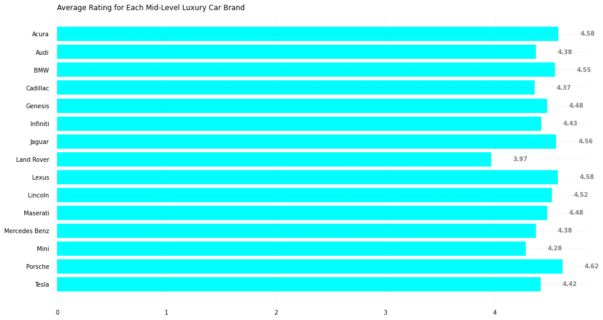

```python
brands = ['Acura', 'Audi', 'BMW', 'Cadillac', 'Genesis', 'Infiniti', 'Jaguar', 'Land Rover', 'Lexus', 'Lincoln',
          'Maserati', 'Mercedes Benz', 'Mini', 'Porsche', 'Tesla']

averages = [df_acura_sample_mean, df_audi_sample_mean, df_bmw_sample_mean, df_cadillac_sample_mean,
            df_genesis_sample_mean,df_infiniti_sample_mean, df_jaguar_sample_mean, df_landrover_sample_mean,
            df_lexus_sample_mean, df_lincoln_sample_mean, df_maserati_sample_mean, df_mercedesbenz_sample_mean,
            df_mini_sample_mean, df_porsche_sample_mean, df_tesla_sample_mean]
plt.show()




# Figure Size
fig, ax = plt.subplots(figsize =(16, 9))

# Horizontal Bar Plot
ax.barh(brands, averages, color = 'cyan')

# Remove axes splines
for s in ['top', 'bottom', 'left', 'right']:
    ax.spines[s].set_visible(False)

# Remove x, y Ticks
ax.xaxis.set_ticks_position('none')
ax.yaxis.set_ticks_position('none')

# Add padding between axes and labels
ax.xaxis.set_tick_params(pad = 5)
ax.yaxis.set_tick_params(pad = 10)

# Add x, y gridlines
ax.grid(b = True, color ='grey',
        linestyle ='-.', linewidth = 0.5,
        alpha = 0.2)

# Show top values
ax.invert_yaxis()

# Add annotation to bars
for i in ax.patches:
    plt.text(i.get_width()+0.2, i.get_y()+0.5,
             str(round((i.get_width()), 2)),
             fontsize = 10, fontweight ='bold',
             color ='grey')

# Add Plot Title
ax.set_title('Average Rating for Each Mid-Level Luxury Car Brand',
             loc ='left', )

plt.show()
```

This visualization is a bar graph simple, but gives us all we need. This verifies my intial thoughts about the worst brand, Land Rover, but it does not for best brand. I knew that Land Rover had lots of issues but I did not expect it to be at less than four stars because it still has enormous appeal. I was suprised to see Porsche with such high ratings given the expensive cost of maintence, I did however expect for Mercedes-Benz to be in the top 3. It is important to note that this is only taken from a sample of the thousands of reviews and still for Genesis with only 77 total reviews they are consistent.

So far we see that Porsche has the highest customer rating at an average 4.62 stars followed by Acura and Lexus tied in second place at 4.58 stars, and Jaguar in third place at 4.56 stars. We also see that Land Rover and Mini have the lowest rating among all 15 brands at being measured at 3.97 and 4.28 respectively.

# Standardization

```python
frames = [df_acura_sample,df_audi_sample, df_bmw_sample, df_cadillac_sample, df_genesis_sample, df_infiniti_sample,
          df_jaguar_sample, df_landrover_sample, df_lexus_sample, df_lincoln_sample, df_maserati_sample,
          df_mercedesbenz_sample, df_mini_sample, df_porsche_sample, df_tesla_sample]

joined_frames = pd.concat(frames)
joined_frames
```

|  | Unnamed: 0 | Review_Date | Vehicle_Title | Review_Title | Review | Rating\r |
| --- | --- | --- | --- | --- | --- | --- |
| 3005 | 3005 | on 05/24/16 13:52 PM (PDT) | 2015 Acura TLX Sedan Technology Package 4dr Se... | Terrible transmission |  | 2.000 |
| 3030 | 3030 | on 10/12/15 12:40 PM (PDT) | 2015 Acura TLX Sedan Technology Package 4dr Se... | Good fuel economy paired with good performance | Great car so far. Nice and responsive, yes t... | 5.000 |
| 1980 | 1980 | on 06/15/07 07:09 AM (PDT) | 2007 Acura TL Type-S Type-S 4dr Sedan w/Summer... | Much Better than an Accord, BMW, Lexus | This is a great buy for an entry-level luxury... | 4.750 |
| 5559 | 5559 | on 12/08/10 05:35 AM (PST) | 2011 Acura MDX SUV Technology and Entertainmen... | False MPG Claim! | I have a 2010 MDX Tech Package/entertainment ... | 3.500 |
| 4008 | 4008 | on 01/11/07 18:51 PM (PST) | 2006 Acura RL Sedan 3.5 4dr Sedan AWD w/Navi S... | My favorite car, unfortunately totaled | Fun car to drive, unfortunately I totaled it ... | 4.875 |
| ... | ... | ... | ... | ... | ... | ... |
| 8 | 8 | on 12/15/17 21:31 PM (PST) | 2016 Tesla Model X SUV 90D 4dr SUV AWD (electr... | Model X is fun to drive but has glitches | My Model X has konked out twice and had to be... | 4.000 |
| 39 | 39 | on 09/08/18 08:14 AM (PDT) | 2017 Tesla Model 3 Sedan Long Range 4dr Sedan ... | Best Electric Car yet | First, the Edmund’s review has errors: car ch... | 5.000 |
| 10 | 10 | on 10/24/17 06:48 AM (PDT) | 2016 Tesla Model X SUV 90D 4dr SUV AWD (electr... | Best vehicle on this planet | Attention! If you have problems navigating yo... | 5.000 |
| 50 | 50 | on 06/30/18 19:30 PM (PDT) | 2017 Tesla Model 3 Sedan Long Range 4dr Sedan ... | old guy with a new toy | the three best pieces of machinery in my life... | 5.000 |
| 82 | 82 | on 05/09/18 09:56 AM (PDT) | 2017 Tesla Model S Sedan 100D 4dr Sedan AWD (e... | "Range Anxiety" is the rule of the day | My wife and I loved everything about this car... | 4.000 |

3375 rows × 6 columns

# Conclusion

Unfortunately, Most car brands had pretty high reviews so it was hard to pick a distinct front runner. However, this does not mean that there isn't other ways to determine this. With more factors in the equation such as period of ownership, making a more certain recommendation could come easier.

So when determining what car to buy based on customer reviews, pay more attention to the content in their review rather than the rating given. One potential question I could further explore: which car buying websites have the most helpful reviews. In this tutorial, I focused more on the exploration of the data. I hope that you now have a good understanding of how exploratory data analysis can be useful and that you see there are many possible approaches.

For more information:

Wrangling

NumPy: https://docs.scipy.org/doc/numpy-dev/user/quickstart.html

Pandas: http://pandas.pydata.org/pandas-docs/stable/

Plotting

Plotly: https://plot.ly/python/

Matplotlib: http://matplotlib.org/contents.html

Seaborn: https://seaborn.pydata.org/